# Problem Sets

#### b) How many degrees of freedom does this analysis have?

#### c) What is the t-statistic?

#### d) What is your final conclusion about the slope?

#### e) What is the variation explained, R2?

#### f) Make a scatterplot of the data and include a linear regression line

#### g) Check the model assumptions

```r
# Libraries
library(performance) # assess model quality and goodness of fit
library(see)         # plotting, extras for ggplot2


# Read in the data
face_rawdata <- read.table(file = "R06_regression/data/face.txt", sep = "\t", header = TRUE)

# Explore data
class(face_rawdata)
```

```
## [1] "data.frame"
```

```r
colnames(face_rawdata)
```

```
## [1] "Face"    "Penalty"
```

```r
head(face_rawdata)
```

```
##   Face Penalty
## 1 1.59    0.44
## 2 1.67    1.43
## 3 1.65    1.57
## 4 1.72    0.14
## 5 1.79    0.27
## 6 1.77    0.35
```

```r
nrow(face_rawdata)
```

```
## [1] 21
```

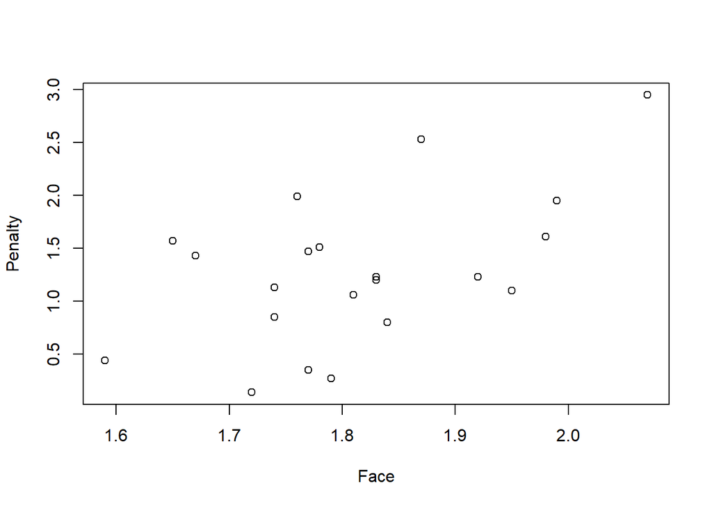

```r
# Quick scatterplot using base R
plot(face_rawdata)
```

```r
plot(face_rawdata$Face, face_rawdata$Penalty) # Alternative code to assign x and y variables

# Linear model
face_lm <- lm(Penalty ~ Face, data=face_rawdata)
summary(face_lm)
```

```
##
## Call:
## lm(formula = Penalty ~ Face, data = face_rawdata)
##
## Residuals:
##     Min      1Q  Median      3Q     Max
## -0.9338 -0.3883 -0.1260  0.3381  1.0711
##
## Coefficients:
##             Estimate Std. Error t value Pr(>|t|)
## (Intercept)   -4.505      2.089  -2.157   0.0440 *
## Face           3.189      1.150   2.774   0.0121 *
## ---
## Signif. codes:  0 '***' 0.001 '**' 0.01 '*' 0.05 '.' 0.1 ' ' 1
##
## Residual standard error: 0.6129 on 19 degrees of freedom
## Multiple R-squared:  0.2882, Adjusted R-squared:  0.2508
## F-statistic: 7.694 on 1 and 19 DF,  p-value: 0.0121
```

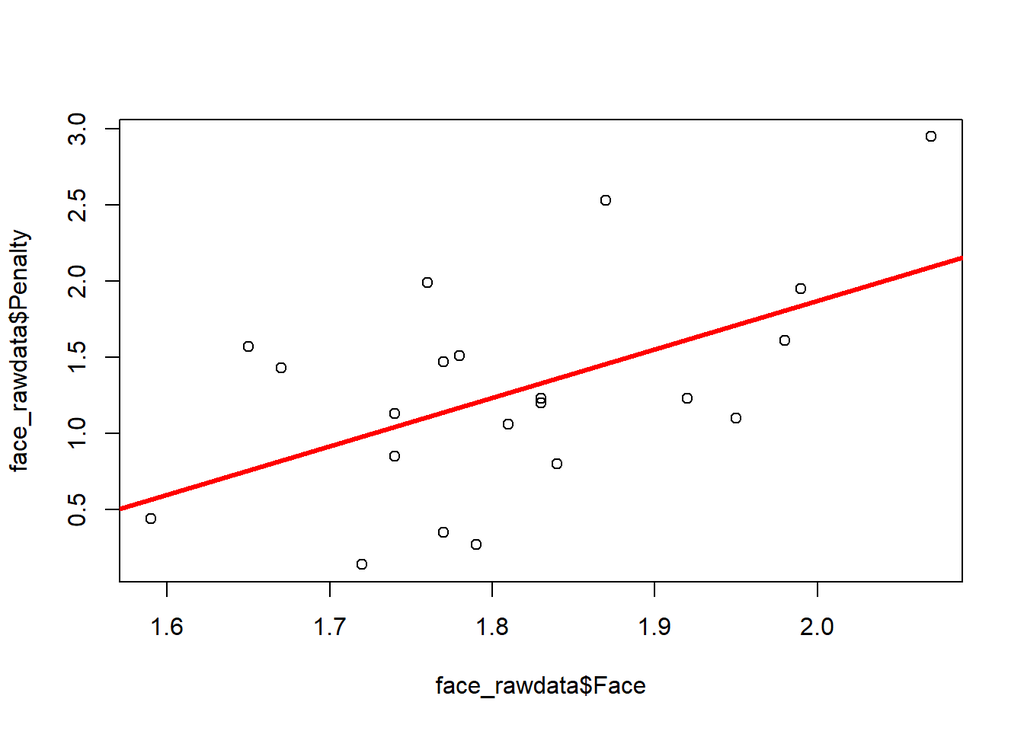

```r
abline(face_lm, col = "red", lwd = 3)
```

```r
# summary(face_lm) tells us answers to a-e.
# But we can extract each individually and print the answers... if we're so inclined:

face_slope     <- round(coef(face_lm)[2],3)
face_intercept <- round(coef(face_lm)[1],3)
face_df        <- face_lm$df.residual
face_t_value   <- round(summary(face_lm)$coefficients[2, "t value"], 3)
face_p_value   <- round(summary(face_lm)$coefficients[2, "Pr(>|t|)"], 3)
face_r_squared <- round(summary(face_lm)$r.squared,3)


cat("Answer to questions:", "\n",
    "a) The equation is: Penalty =", face_intercept, "+", face_slope, "* Face", "\n",
    "b) Degrees of Freedom:", face_df, "\n",
    "c) t-value for Face variable:", face_t_value, " (p-value:", face_p_value, ")", "\n",
    "d) The slope of the relationship between Face and Penalty is positive and statistically significant.", "\n",
    "e) R-squared:", face_r_squared, "\n")
```

```
## Answer to questions:
##  a) The equation is: Penalty = -4.505 + 3.189 * Face
##  b) Degrees of Freedom: 19
##  c) t-value for Face variable: 2.774  (p-value: 0.012 )
##  d) The slope of the relationship between Face and Penalty is positive and statistically significant.
##  e) R-squared: 0.288
```

```r
# Check model assumptions
check_model(face_lm)
```

```
## Not enough model terms in the conditional part of the model to check for
##   multicollinearity.
```

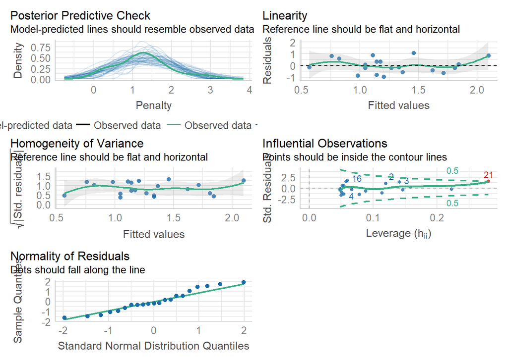

### **Question 2**

#### Respiratory rate (Y) is expected to depend on body mass (X) by the power law, Power Law: Y=aX^beta, where beta is the scaling exponent. The data are available in respiratoryrate_bodymass.txt.

#### a) Make a scatterplot of the raw data

#### b) Make a scatterplot of the linearized relationship. Which transformation did you use?

#### c) Use linear regression to estimate beta

#### d) Carry out a formal test of the null hypothesis of beta=0.

#### e) What is the variation explained, R2?

#### f) Check the model assumptions

```r
# Read in data
bodymass <- read.table(file = "R06_regression/data/respiratoryrate_bodymass.txt", sep = "\t", header = TRUE)

# Explore
class(bodymass)
```

```
## [1] "data.frame"
```

```r
colnames(bodymass)
```

```
## [1] "BodyMass"    "Respiration"
```

```r
nrow(bodymass)
```

```
## [1] 10
```

```r
head(bodymass)
```

```
##   BodyMass Respiration
## 1      453         666
## 2     1283         643
## 3      695        1512
## 4     1640        2198
## 5     1207        2535
## 6     2096        4176
```

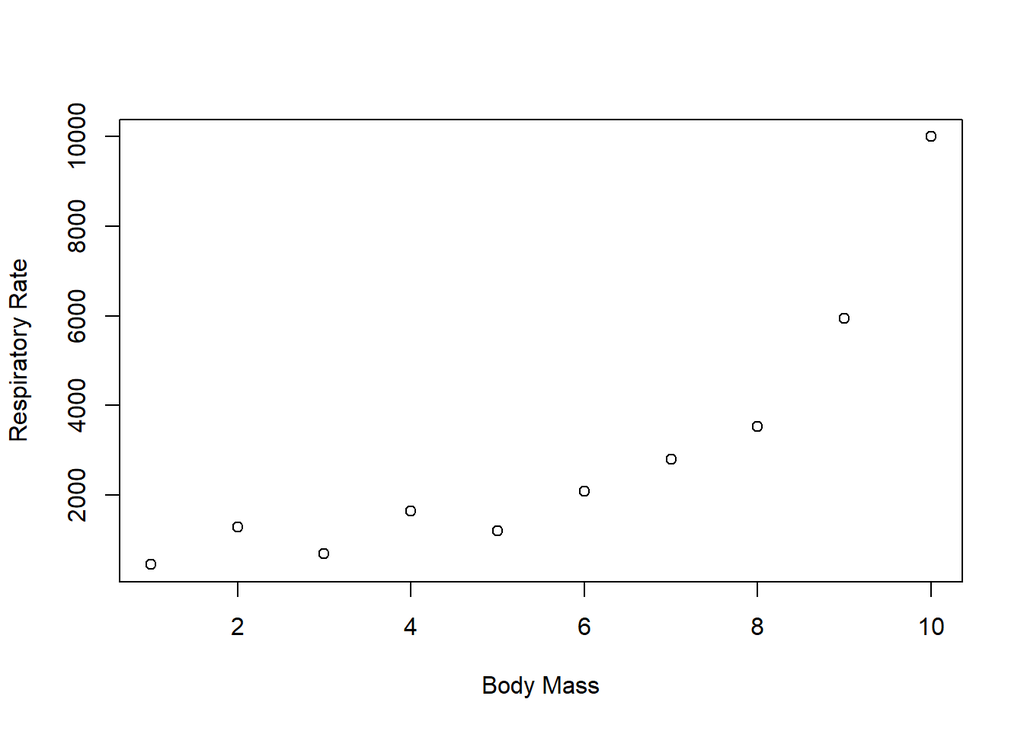

```r
# ========================================
# Scatterplots ===========================
# ========================================

# Scatterplot using base R
plot(bodymass$BodyMass, bodymass$RespiratoryRate,
     xlab = "Body Mass",
     ylab = "Respiratory Rate")
```

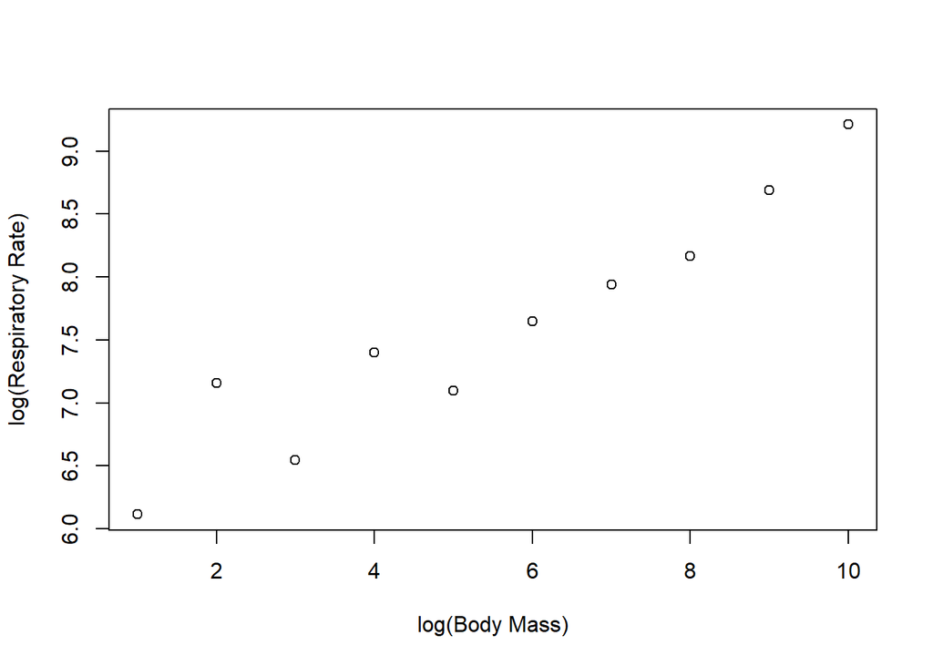

```r
# Take the logarithm of both variables
logdata <- log(bodymass)

# Make a scatterplot of the linearized relationship
plot(logdata$BodyMass, logdata$RespiratoryRate,
     xlab = "log(Body Mass)",
     ylab = "log(Respiratory Rate)")
```

```r
# ==================================================
# Use linear regression to estimate beta ===========
# ==================================================

# Fit a linear regression model to the transformed data
logdata_lm <- lm(logdata$Respiration ~ logdata$BodyMass, data = logdata)
summary(logdata_lm)
```

```
##
## Call:
## lm(formula = logdata$Respiration ~ logdata$BodyMass, data = logdata)
##
## Residuals:
##      Min       1Q   Median       3Q      Max
## -1.01062 -0.08150  0.00831  0.30669  0.43948
##
## Coefficients:
##                  Estimate Std. Error t value Pr(>|t|)
## (Intercept)        1.3401     1.2011   1.116 0.296938
## logdata$BodyMass   0.8574     0.1570   5.461 0.000601 ***
## ---
## Signif. codes:  0 '***' 0.001 '**' 0.01 '*' 0.05 '.' 0.1 ' ' 1
##
## Residual standard error: 0.4449 on 8 degrees of freedom
## Multiple R-squared:  0.7885, Adjusted R-squared:  0.762
## F-statistic: 29.82 on 1 and 8 DF,  p-value: 0.000601
```

```r
# Extract the coefficient for the BodyMass predictor variable
logbeta <- coef(logdata_lm)[2]
# beta <- coef(logdata_lm)["logdata$BodyMass"]      # alternative code
cat("Logged Beta:", logbeta, "\n")
```

```
## Logged Beta: 0.8574374
```

```r
# Exponentiate the logbeta coefficient to get the beta for the Power Law
beta <- exp(logbeta)
cat("Beta:", beta, "\n")
```

```
## Beta: 2.357112
```

```r
# Carry out a formal test of the null hypothesis of beta=0.
# Look at the t-value ???
summary(logdata_lm)
```

```
##
## Call:
## lm(formula = logdata$Respiration ~ logdata$BodyMass, data = logdata)
##
## Residuals:
##      Min       1Q   Median       3Q      Max
## -1.01062 -0.08150  0.00831  0.30669  0.43948
##
## Coefficients:
##                  Estimate Std. Error t value Pr(>|t|)
## (Intercept)        1.3401     1.2011   1.116 0.296938
## logdata$BodyMass   0.8574     0.1570   5.461 0.000601 ***
## ---
## Signif. codes:  0 '***' 0.001 '**' 0.01 '*' 0.05 '.' 0.1 ' ' 1
##
## Residual standard error: 0.4449 on 8 degrees of freedom
## Multiple R-squared:  0.7885, Adjusted R-squared:  0.762
## F-statistic: 29.82 on 1 and 8 DF,  p-value: 0.000601
```

```r
summary(logdata_lm)$coefficients
```

```
##                   Estimate Std. Error  t value    Pr(>|t|)
## (Intercept)      1.3401278  1.2011499 1.115704 0.296938084
## logdata$BodyMass 0.8574374  0.1570202 5.460680 0.000601046
```

```r
summary(logdata_lm)$r.squared
```

```
## [1] 0.7884663
```

```r
# Check model assumptions
library(gvlma)
check_model(logdata_lm)
```

```
## Not enough model terms in the conditional part of the model to check for
##   multicollinearity.
```

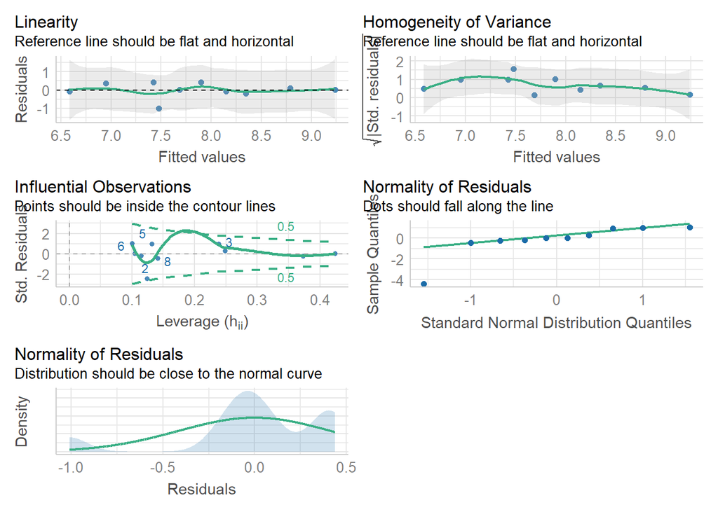

```r
summary(gvlma(logdata_lm))
```

```
##
## Call:
## lm(formula = logdata$Respiration ~ logdata$BodyMass, data = logdata)
##
## Residuals:
##      Min       1Q   Median       3Q      Max
## -1.01062 -0.08150  0.00831  0.30669  0.43948
##
## Coefficients:
##                  Estimate Std. Error t value Pr(>|t|)
## (Intercept)        1.3401     1.2011   1.116 0.296938
## logdata$BodyMass   0.8574     0.1570   5.461 0.000601 ***
## ---
## Signif. codes:  0 '***' 0.001 '**' 0.01 '*' 0.05 '.' 0.1 ' ' 1
##
## Residual standard error: 0.4449 on 8 degrees of freedom
## Multiple R-squared:  0.7885, Adjusted R-squared:  0.762
## F-statistic: 29.82 on 1 and 8 DF,  p-value: 0.000601
##
##
## ASSESSMENT OF THE LINEAR MODEL ASSUMPTIONS
## USING THE GLOBAL TEST ON 4 DEGREES-OF-FREEDOM:
## Level of Significance =  0.05
##
## Call:
##  gvlma(x = logdata_lm)
##
##                     Value p-value                Decision
## Global Stat        7.3733 0.11743 Assumptions acceptable.
## Skewness           2.9044 0.08834 Assumptions acceptable.
## Kurtosis           0.9461 0.33071 Assumptions acceptable.
## Link Function      0.0425 0.83667 Assumptions acceptable.
## Heteroscedasticity 3.4803 0.06210 Assumptions acceptable.
```

## **Problem Set 7: Statistical Modeling**

### **Question 1**

#### Use the ozone.txt data to model the ozone concentration as a linear function of wind speed, air temperature and the intensity of solar radiation. Assume that the requirements to perform a linear regression are met.

#### a) Make a multiple panel bivariate scatterplot

#### b) Perform a multiple linear regression

#### c) What is the variation explained, R2?

#### d) Assess the co-linearity of the explanatory variables using the variance inflation factor

#### e) Check the model assumptions

```r
# Libraries
library(car)         # regression
```

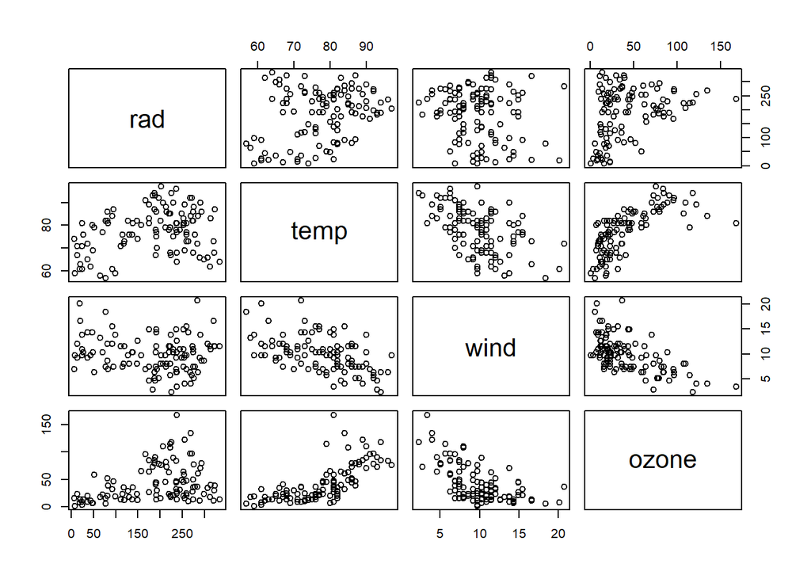

```r
# Read in the data
ozone <- read.csv(file = "R07_statistical_modeling/data/ozone.txt", sep="\t", header=T)

# Multiple panel bivariate scatterplot
pairs(ozone)
```

```r
# Multiple linear regression
model_lm <- lm(ozone ~ wind + temp + rad, data = ozone)

# R^2
summary(model_lm)
```

```
##
## Call:
## lm(formula = ozone ~ wind + temp + rad, data = ozone)
##
## Residuals:
##     Min      1Q  Median      3Q     Max
## -40.485 -14.210  -3.556  10.124  95.600
##
## Coefficients:
##              Estimate Std. Error t value Pr(>|t|)
## (Intercept) -64.23208   23.04204  -2.788  0.00628 **
## wind         -3.33760    0.65384  -5.105 1.45e-06 ***
## temp          1.65121    0.25341   6.516 2.43e-09 ***
## rad           0.05980    0.02318   2.580  0.01124 *
## ---
## Signif. codes:  0 '***' 0.001 '**' 0.01 '*' 0.05 '.' 0.1 ' ' 1
##
## Residual standard error: 21.17 on 107 degrees of freedom
## Multiple R-squared:  0.6062, Adjusted R-squared:  0.5952
## F-statistic: 54.91 on 3 and 107 DF,  p-value: < 2.2e-16
```

```r
# Co-linearity using variation inflation factor
# If any VIF values are >5, then there may be co-linearity issues.
vif(model_lm)
```

```
##     wind     temp      rad
## 1.328979 1.431201 1.095241
```

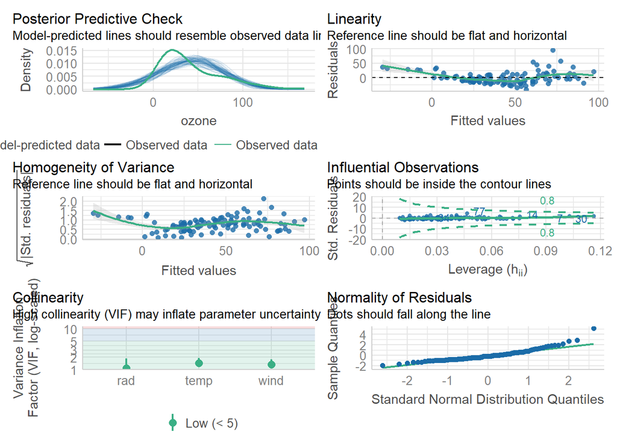

```r
# Model diagnostics
check_model(model_lm)
```

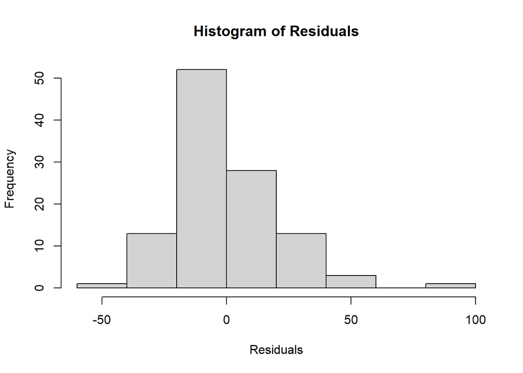

```r
hist(resid(model_lm), main = "Histogram of Residuals", xlab = "Residuals")
```

### **Question 2**

#### a) Perform a simple linear regression

```r
# Read in data
bodymass <- read.table(file = "R07_statistical_modeling/data/respiratoryrate_bodymass (1).txt", sep = "\t", header = TRUE)

# Explore
class(bodymass)
```

```
## [1] "data.frame"
```

```r
colnames(bodymass)
```

```
## [1] "BodyMass"    "Respiration"
```

```r
nrow(bodymass)
```

```
## [1] 10
```

```r
head(bodymass)
```

```
##   BodyMass Respiration
## 1      453         666
## 2     1283         643
## 3      695        1512
## 4     1640        2198
## 5     1207        2535
## 6     2096        4176
```

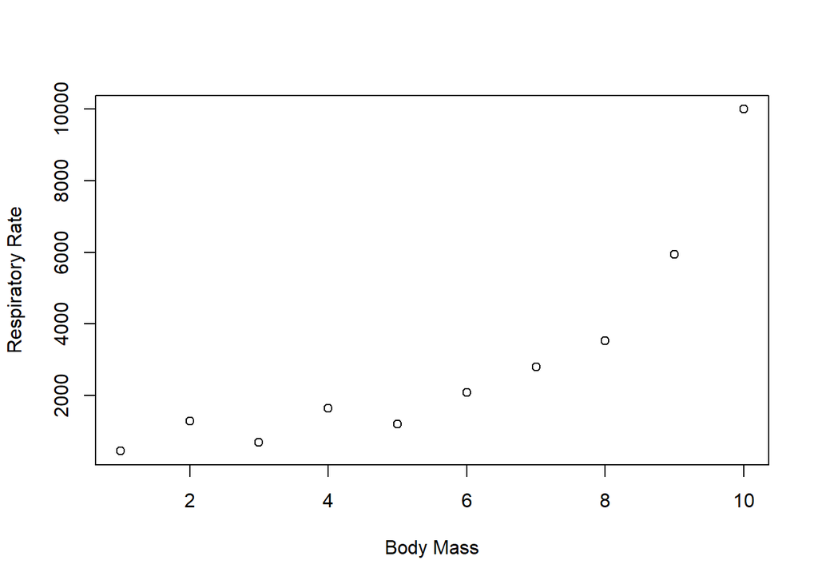

```r
# ========================================
# Scatterplots ===========================
# ========================================

# Scatterplot using base R
plot(bodymass$BodyMass, bodymass$RespiratoryRate,
     xlab = "Body Mass",
     ylab = "Respiratory Rate")
```

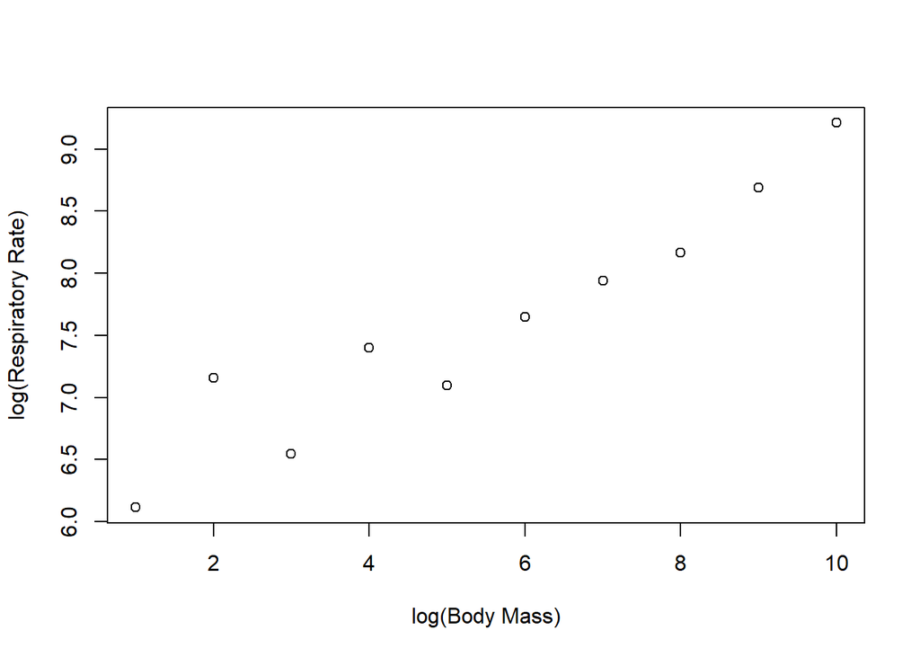

```r
# Take the logarithm of both variables
logdata <- log(bodymass)

# Make a scatterplot of the linearized relationship
plot(logdata$BodyMass, logdata$RespiratoryRate,
     xlab = "log(Body Mass)",
     ylab = "log(Respiratory Rate)")
```

```r
# ==================================================
# Use linear regression to estimate beta ===========
# ==================================================

# Fit a linear regression model to the transformed data
logdata_lm <- lm(logdata$Respiration ~ logdata$BodyMass, data = logdata)
summary(logdata_lm)
```

```
##
## Call:
## lm(formula = logdata$Respiration ~ logdata$BodyMass, data = logdata)
##
## Residuals:
##      Min       1Q   Median       3Q      Max
## -1.01062 -0.08150  0.00831  0.30669  0.43948
##
## Coefficients:
##                  Estimate Std. Error t value Pr(>|t|)
## (Intercept)        1.3401     1.2011   1.116 0.296938
## logdata$BodyMass   0.8574     0.1570   5.461 0.000601 ***
## ---
## Signif. codes:  0 '***' 0.001 '**' 0.01 '*' 0.05 '.' 0.1 ' ' 1
##
## Residual standard error: 0.4449 on 8 degrees of freedom
## Multiple R-squared:  0.7885, Adjusted R-squared:  0.762
## F-statistic: 29.82 on 1 and 8 DF,  p-value: 0.000601
```

```r
# Extract the coefficient for the BodyMass predictor variable
logbeta <- coef(logdata_lm)[2]
# beta <- coef(logdata_lm)["logdata$BodyMass"]      # alternative code
cat("Logged Beta:", logbeta, "\n")
```

```
## Logged Beta: 0.8574374
```

```r
# Exponentiate the logbeta coefficient to get the beta for the Power Law
beta <- exp(logbeta)
cat("Beta:", beta, "\n")
```

```
## Beta: 2.357112
```

```r
# Carry out a formal test of the null hypothesis of beta=0.
# Look at the t-value ???
summary(logdata_lm)
```

```
##
## Call:
## lm(formula = logdata$Respiration ~ logdata$BodyMass, data = logdata)
##
## Residuals:
##      Min       1Q   Median       3Q      Max
## -1.01062 -0.08150  0.00831  0.30669  0.43948
##
## Coefficients:
##                  Estimate Std. Error t value Pr(>|t|)
## (Intercept)        1.3401     1.2011   1.116 0.296938
## logdata$BodyMass   0.8574     0.1570   5.461 0.000601 ***
## ---
## Signif. codes:  0 '***' 0.001 '**' 0.01 '*' 0.05 '.' 0.1 ' ' 1
##
## Residual standard error: 0.4449 on 8 degrees of freedom
## Multiple R-squared:  0.7885, Adjusted R-squared:  0.762
## F-statistic: 29.82 on 1 and 8 DF,  p-value: 0.000601
```

```r
summary(logdata_lm)$coefficients
```

```
##                   Estimate Std. Error  t value    Pr(>|t|)
## (Intercept)      1.3401278  1.2011499 1.115704 0.296938084
## logdata$BodyMass 0.8574374  0.1570202 5.460680 0.000601046
```

```r
summary(logdata_lm)$r.squared
```

```
## [1] 0.7884663
```

```r
# Check model assumptions
check_model(logdata_lm)
```

```
## Not enough model terms in the conditional part of the model to check for
##   multicollinearity.
```

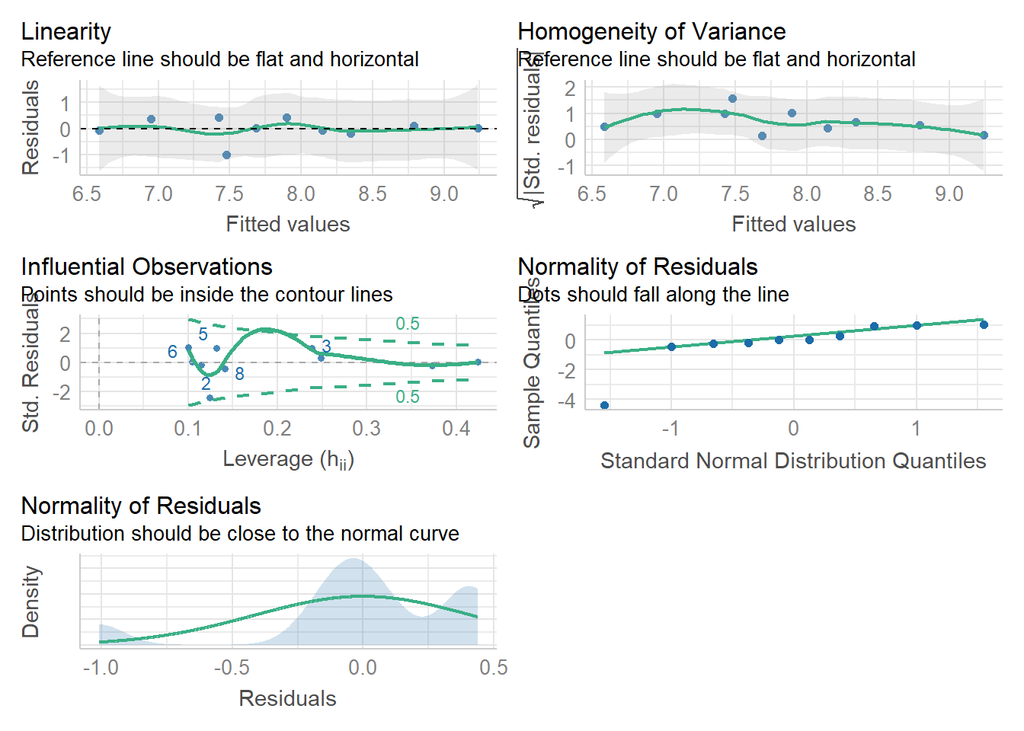

```r
summary(gvlma(logdata_lm))
```

```
##
## Call:
## lm(formula = logdata$Respiration ~ logdata$BodyMass, data = logdata)
##
## Residuals:
##      Min       1Q   Median       3Q      Max
## -1.01062 -0.08150  0.00831  0.30669  0.43948
##
## Coefficients:
##                  Estimate Std. Error t value Pr(>|t|)
## (Intercept)        1.3401     1.2011   1.116 0.296938
## logdata$BodyMass   0.8574     0.1570   5.461 0.000601 ***
## ---
## Signif. codes:  0 '***' 0.001 '**' 0.01 '*' 0.05 '.' 0.1 ' ' 1
##
## Residual standard error: 0.4449 on 8 degrees of freedom
## Multiple R-squared:  0.7885, Adjusted R-squared:  0.762
## F-statistic: 29.82 on 1 and 8 DF,  p-value: 0.000601
##
##
## ASSESSMENT OF THE LINEAR MODEL ASSUMPTIONS
## USING THE GLOBAL TEST ON 4 DEGREES-OF-FREEDOM:
## Level of Significance =  0.05
##
## Call:
##  gvlma(x = logdata_lm)
##
##                     Value p-value                Decision
## Global Stat        7.3733 0.11743 Assumptions acceptable.
## Skewness           2.9044 0.08834 Assumptions acceptable.
## Kurtosis           0.9461 0.33071 Assumptions acceptable.
## Link Function      0.0425 0.83667 Assumptions acceptable.
## Heteroscedasticity 3.4803 0.06210 Assumptions acceptable.
```

### **Question 3**

#### The data in stork.txt display the stress-induced corticosterone levels circulating in the blood of European white storks and their survival over the subsequent five years of study.

#### a) Make a scatterplot of the data

#### b) Which type of regression model is suitable for these data?

#### c) Perform an appropriate regression to predict survival from corticosterone

#### d) What is the pseudo-R2 of the model?

#### e) What is the p-value of the model?

#### f) Include the predicted curve in the scatterplot

#### g) Check the model assumptions

```r
# Libraries
library(ggeffects)   # predicted probabilities
```

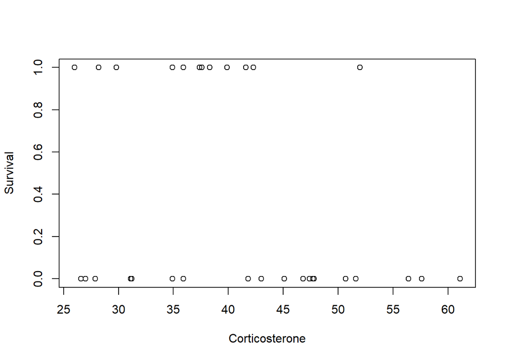

```r
# Load in data
stork <- read.csv(file = "R07_statistical_modeling/data/stork.txt", sep = "\t", header = T)


# Scatterplot
plot(stork)
```

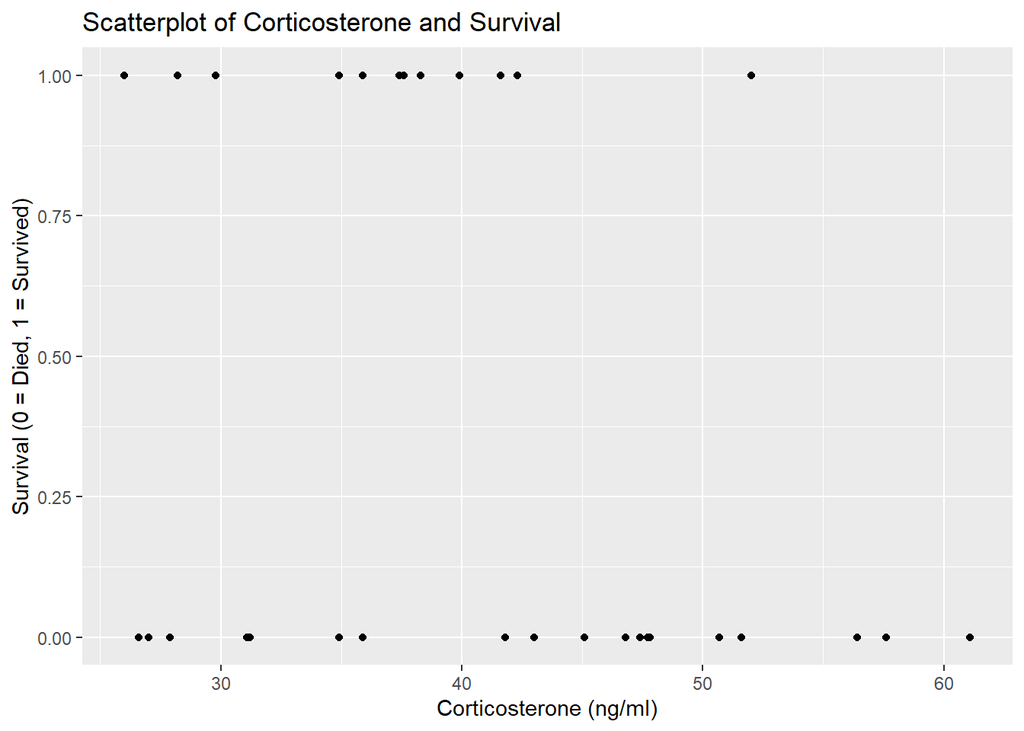

```r
ggplot(stork, aes(x = Corticosterone, y = Survival)) +
  geom_point() +
  labs(title = "Scatterplot of Corticosterone and Survival",
       x = "Corticosterone (ng/ml)",
       y = "Survival (0 = Died, 1 = Survived)")
```

```r
# Binary, so logistic regression is appropriate.

# Logistic regression
model_glm <- glm(Survival ~ Corticosterone, data = stork, family = binomial)
model_glm
```

```
##
## Call:  glm(formula = Survival ~ Corticosterone, family = binomial, data = stork)
##
## Coefficients:
##    (Intercept)  Corticosterone
##         2.7030         -0.0798
##
## Degrees of Freedom: 33 Total (i.e. Null);  32 Residual
## Null Deviance:       45.23
## Residual Deviance: 41.4  AIC: 45.4
```

```r
# Pseudo-R2 of the model
r2(model_glm)
```

```
## # R2 for Logistic Regression
##   Tjur's R2: 0.102
```

```r
# P-value of the model
summary(model_glm)
```

```
##
## Call:
## glm(formula = Survival ~ Corticosterone, family = binomial, data = stork)
##
## Deviance Residuals:
##     Min       1Q   Median       3Q      Max
## -1.4316  -0.8724  -0.6703   1.2125   1.8211
##
## Coefficients:
##                Estimate Std. Error z value Pr(>|z|)
## (Intercept)     2.70304    1.74725   1.547   0.1219
## Corticosterone -0.07980    0.04368  -1.827   0.0677 .
## ---
## Signif. codes:  0 '***' 0.001 '**' 0.01 '*' 0.05 '.' 0.1 ' ' 1
##
## (Dispersion parameter for binomial family taken to be 1)
##
##     Null deviance: 45.234  on 33  degrees of freedom
## Residual deviance: 41.396  on 32  degrees of freedom
## AIC: 45.396
##
## Number of Fisher Scoring iterations: 4
```

```r
# Plot the predicted probabilities of survival
predicted <- ggpredict(model_glm, terms = "Corticosterone")
```

```
## Data were 'prettified'. Consider using `terms="Corticosterone [all]"` to
##   get smooth plots.
```

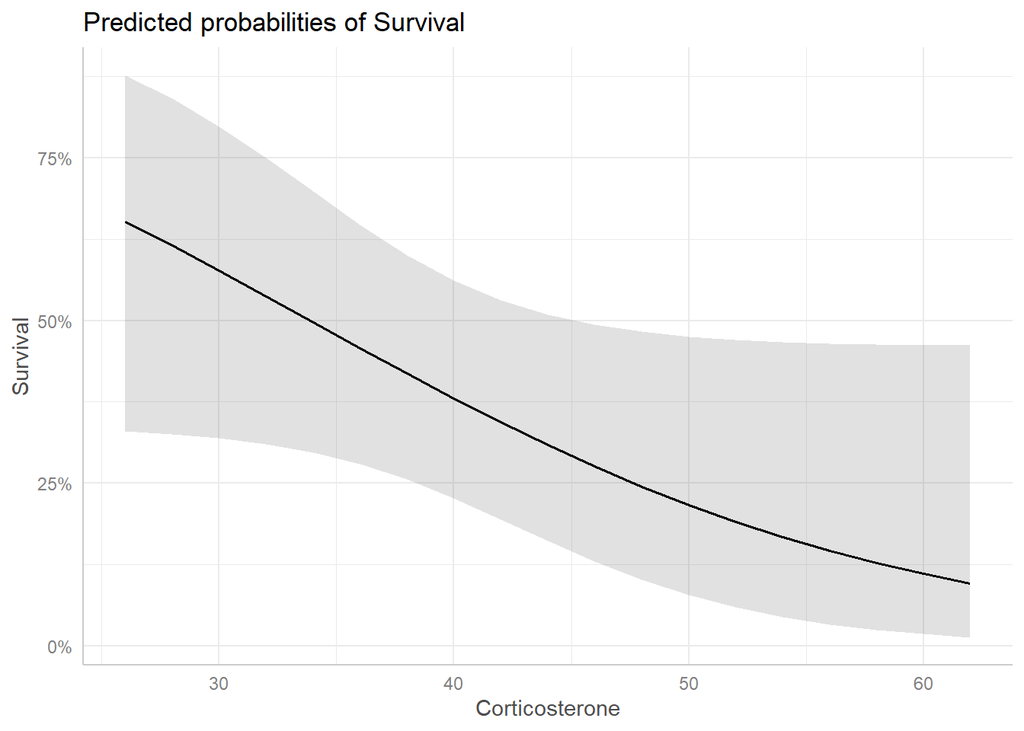

```r
plot(predicted)
```

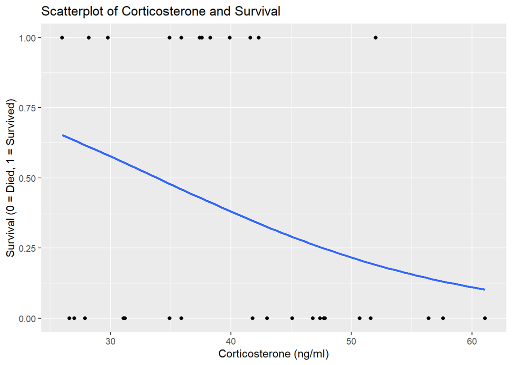

```r
# Plot with logistic regression curve
ggplot(stork, aes(x = Corticosterone, y = Survival)) +
  geom_point() +
  labs(title = "Scatterplot of Corticosterone and Survival",
       x = "Corticosterone (ng/ml)",
       y = "Survival (0 = Died, 1 = Survived)") +
  stat_smooth(method = "glm", method.args = list(family = "binomial"), se = FALSE)
```

```r
# Model diagnostics
check_model(model_glm)
```

```
## Not enough model terms in the conditional part of the model to check for
##   multicollinearity.
```

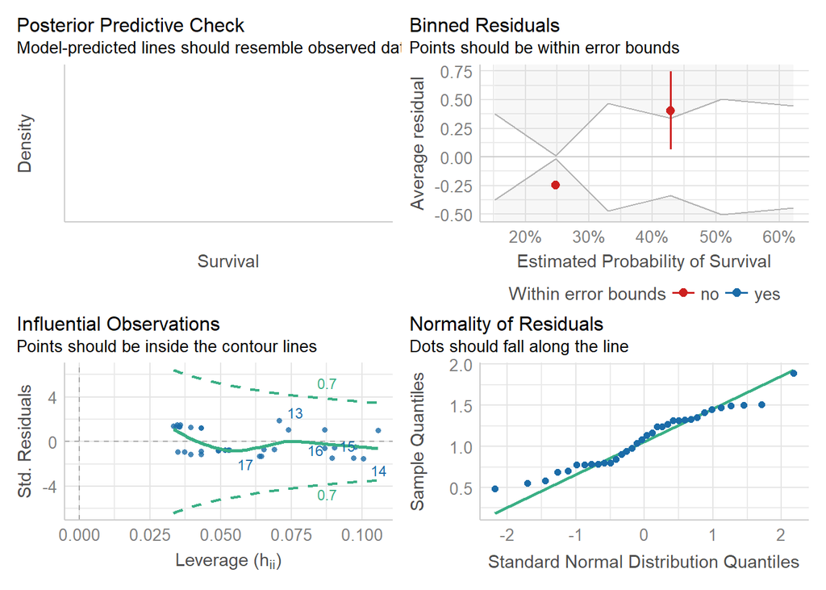

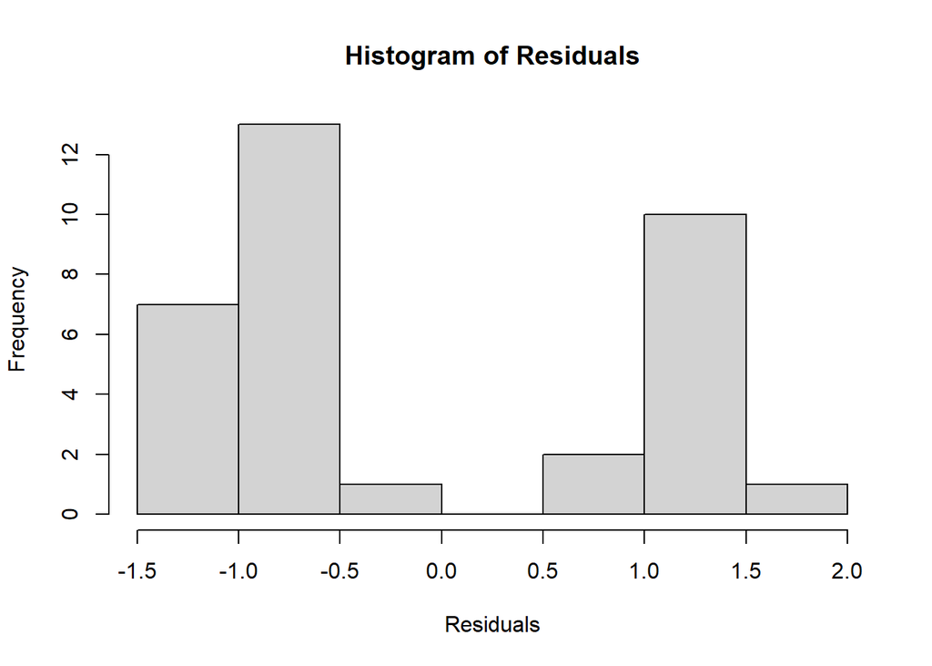

```r
hist(resid(model_glm), main = "Histogram of Residuals", xlab = "Residuals")
```

### **Question 4**

#### The clusters.txt dataset contains the response variable Cancers (cases per year per clinic) and the explanatory variable Distance (the distance from a nuclear plant to the clinic in kilometers).

#### a) Make a scatterplot of the data

#### b) Which regression is the more appropriate for these data? (Don’t take overdispersion into account for now)

#### c) Given your choice, is the trend significant?

#### d) What is the pseudo-R2 of the model?

#### e) What is the p-value of the model?

#### f) Include the predicted relationship from the model in the scatterplot

#### g) Do you think there might be some evidence of overdispersion?

#### h) Perform a new generalized linear model with a distribution that better accounts for overdispersion

#### i) Check this last model assumptions

```r
# Libraries
library(MASS)        # perform negative binomial regression
```

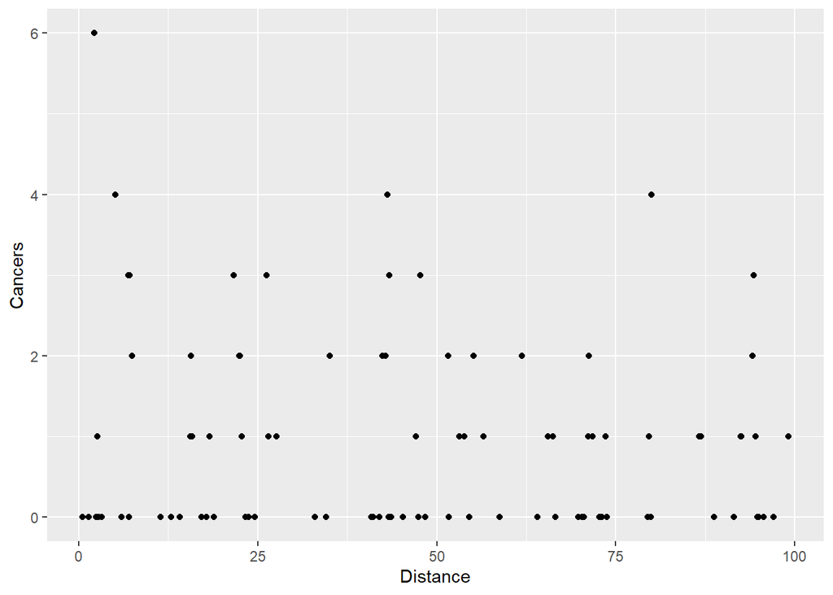

```r
clusters <- read.csv(file = "R07_statistical_modeling/data/clusters.txt", sep = "\t", header = T)

# Make a scatterplot of the data
ggplot(clusters, aes(x=Distance, y=Cancers)) + geom_point()
```

```r
# Which regression is the more appropriate for these data?(Don’t take overdispersion into account for now)
# Since response variable is a count, a Poisson regression model is appropriate.

# Given your choice, is the trend significant?
# Fit a Poisson regression model
model_poisson <- glm(Cancers ~ Distance, data=clusters, family=poisson)
summary(model_poisson)
```

```
##
## Call:
## glm(formula = Cancers ~ Distance, family = poisson, data = clusters)
##
## Deviance Residuals:
##     Min       1Q   Median       3Q      Max
## -1.5504  -1.3491  -1.1553   0.3877   3.1304
##
## Coefficients:
##              Estimate Std. Error z value Pr(>|z|)
## (Intercept)  0.186865   0.188728   0.990   0.3221
## Distance    -0.006138   0.003667  -1.674   0.0941 .
## ---
## Signif. codes:  0 '***' 0.001 '**' 0.01 '*' 0.05 '.' 0.1 ' ' 1
##
## (Dispersion parameter for poisson family taken to be 1)
##
##     Null deviance: 149.48  on 93  degrees of freedom
## Residual deviance: 146.64  on 92  degrees of freedom
## AIC: 262.41
##
## Number of Fisher Scoring iterations: 5
```

```r
# p-value 0.0941 > 0.05 ; not significant

# What is the pseudo-R2 of the model?
r2(model_poisson)
```

```
## # R2 for Generalized Linear Regression
##   Nagelkerke's R2: 0.037
```

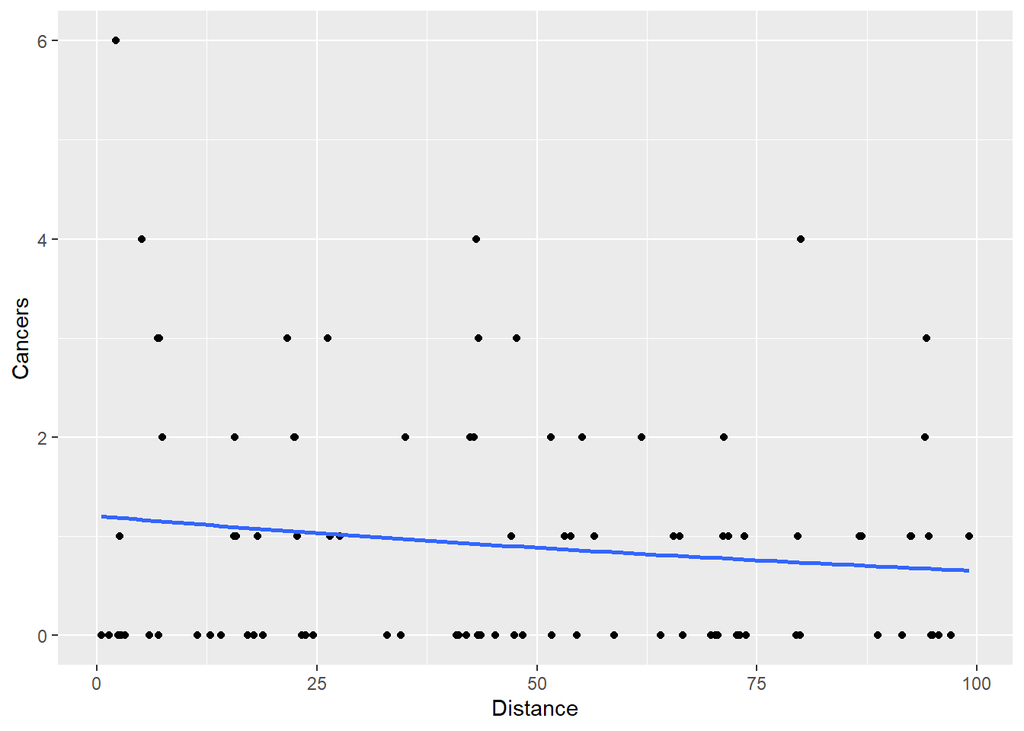

```r
# Include the predicted relationship from the model in the scatterplot
ggplot(clusters, aes(x=Distance, y=Cancers)) +
  geom_point() +
  geom_smooth(method="glm", method.args=list(family="poisson"), se=FALSE)
```

```r
# Do you think there might be some evidence of overdispersion?
check_overdispersion(model_poisson)
```

```
## # Overdispersion test
##
##        dispersion ratio =   1.555
##   Pearson's Chi-Squared = 143.071
##                 p-value =   0.001
```

```
## Overdispersion detected.
```

```r
# Perform a new generalized linear model with a distribution that better accounts for overdispersion
# Negative binomial regression model
model_nb <- glm.nb(Cancers ~ Distance, data=clusters)
summary(model_nb)
```

```
##
## Call:
## glm.nb(formula = Cancers ~ Distance, data = clusters, init.theta = 1.359466981,
##     link = log)
##
## Deviance Residuals:
##     Min       1Q   Median       3Q      Max
## -1.3103  -1.1805  -1.0442   0.3065   1.9582
##
## Coefficients:
##              Estimate Std. Error z value Pr(>|z|)
## (Intercept)  0.182490   0.252434   0.723    0.470
## Distance    -0.006041   0.004727  -1.278    0.201
##
## (Dispersion parameter for Negative Binomial(1.3595) family taken to be 1)
##
##     Null deviance: 96.647  on 93  degrees of freedom
## Residual deviance: 94.973  on 92  degrees of freedom
## AIC: 253.19
##
## Number of Fisher Scoring iterations: 1
##
##
##               Theta:  1.359
##           Std. Err.:  0.612
##
##  2 x log-likelihood:  -247.191
```

```r
# Check this last model assumptions
# Model diagnostics
check_model(model_nb)
```

```
## Not enough model terms in the conditional part of the model to check for
##   multicollinearity.
```

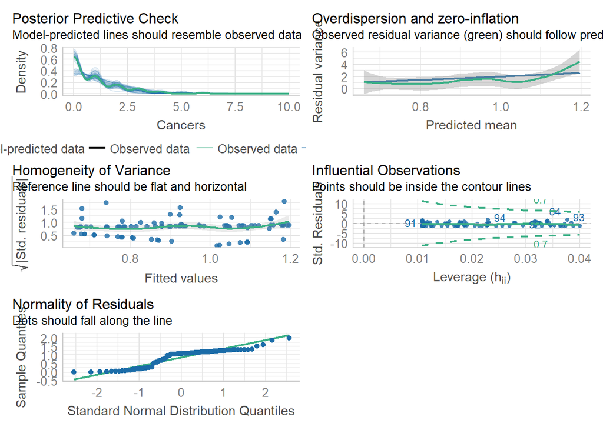

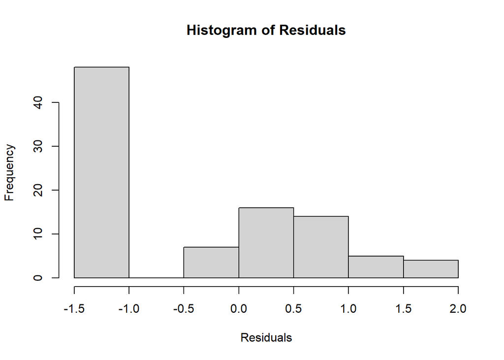

```r
hist(resid(model_nb), main = "Histogram of Residuals", xlab = "Residuals")
```

### **Question 5**

#### Use the jaws.txt data to:

#### a) Make a scatterplot of the data (age explanatory, bone response)

#### b) Perform a non-linear regression assuming an asymptotic exponential relationship:

#### y=a(1-e^(-cx))

#### c) Perform a non-linear regression assuming a Michaelis-Menten model:

#### y=ax/(1+bx)

#### d) Estimate the percentage of variation explained by both models (comparing them with a null model with only a constant)

#### e) Compare both models with Akaike’s Information Criterion (AIC). Which model is better?

#### f) Make a scatterplot of the data and include both regression lines

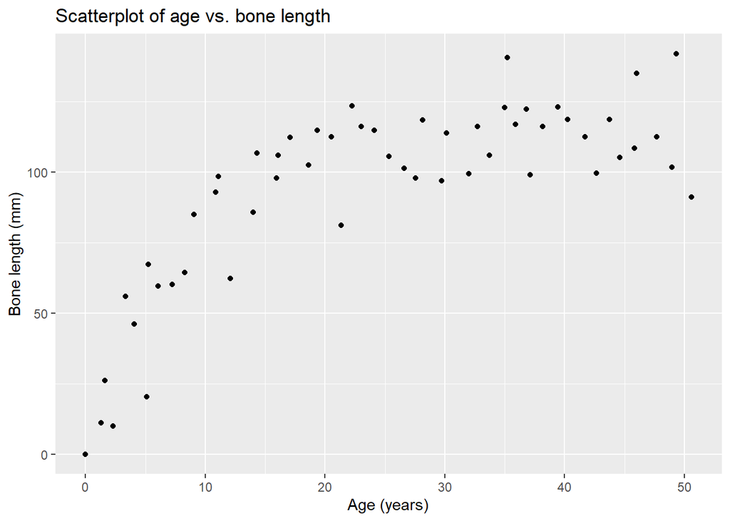

```r
# Read in data
jaws <- read.csv(file = "R07_statistical_modeling/data/jaws.txt", sep = "\t", header = T)

# a) Make a scatterplot of the data (age explanatory, bone response)
ggplot(jaws, aes(x = age, y = bone)) +
  geom_point() +
  labs(x = "Age (years)", y = "Bone length (mm)",
       title = "Scatterplot of age vs. bone length")
```

```r
# b) Perform a non-linear regression assuming an asymptotic exponential relationship:
#   y=a(1-e^(-cx))

# "a" is the estimated maximum bone length
range(jaws$bone) # 142
```

```
## [1]   0 142
```

```r
# Regression to get the "c" starting value
jaws_lm <- lm(bone ~ age, data = jaws)
summary(jaws_lm) # slope = 1.642
```

```
##
## Call:
## lm(formula = bone ~ age, data = jaws)
##
## Residuals:
##     Min      1Q  Median      3Q     Max
## -53.259 -10.457   2.353  18.048  33.589
##
## Coefficients:
##             Estimate Std. Error t value Pr(>|t|)
## (Intercept)   53.259      5.837   9.124 2.23e-12 ***
## age            1.642      0.201   8.166 6.97e-11 ***
## ---
## Signif. codes:  0 '***' 0.001 '**' 0.01 '*' 0.05 '.' 0.1 ' ' 1
##
## Residual standard error: 22.3 on 52 degrees of freedom
## Multiple R-squared:  0.5619, Adjusted R-squared:  0.5534
## F-statistic: 66.68 on 1 and 52 DF,  p-value: 6.968e-11
```

```r
# The starting value for parameter c is estimated by taking the reciprocal
# of the slope of the linear regression between age and bone length.
# c = 1/1.642 = 0.6088
exp_model <- nls(bone ~ a*(1-exp(-c*age)), data = jaws, start = list(a = 142, c = 0.6088))
summary(exp_model)
```

```
##
## Formula: bone ~ a * (1 - exp(-c * age))
##
## Parameters:
##    Estimate Std. Error t value Pr(>|t|)
## a 115.58052    2.84364  40.645  < 2e-16 ***
## c   0.11882    0.01233   9.635 3.69e-13 ***
## ---
## Signif. codes:  0 '***' 0.001 '**' 0.01 '*' 0.05 '.' 0.1 ' ' 1
##
## Residual standard error: 13.1 on 52 degrees of freedom
##
## Number of iterations to convergence: 6
## Achieved convergence tolerance: 1.423e-06
```

```r
# c) Perform a non-linear regression assuming a Michaelis-Menten model:
#   y=ax/(1+bx)
mm_model <- nls(bone ~ a*age/(1+b*age), data = jaws, start = list(a = 142, b = 0.6088))
summary(mm_model)
```

```
##
## Formula: bone ~ a * age/(1 + b * age)
##
## Parameters:
##   Estimate Std. Error t value Pr(>|t|)
## a 18.72540    2.52587   7.413 1.09e-09 ***
## b  0.13596    0.02339   5.814 3.79e-07 ***
## ---
## Signif. codes:  0 '***' 0.001 '**' 0.01 '*' 0.05 '.' 0.1 ' ' 1
##
## Residual standard error: 13.77 on 52 degrees of freedom
##
## Number of iterations to convergence: 8
## Achieved convergence tolerance: 2.686e-06
```

```r
# d) Estimate the percentage of variation explained by both models
# (comparing them with a null model with only a constant)
null_model <- lm(bone ~ 1, data = jaws)
1 - (sum(residuals(exp_model)^2)/sum(residuals(null_model)^2))
```

```
## [1] 0.8486791
```

```r
1 - (sum(residuals(mm_model)^2)/sum(residuals(null_model)^2))
```

```
## [1] 0.8329987
```

```r
# e) Compare both models with Akaike’s Information Criterion (AIC).
# Which model is better?
AIC(exp_model)
```

```
## [1] 435.0823
```

```r
AIC(mm_model) # higher AIC
```

```
## [1] 440.4066
```

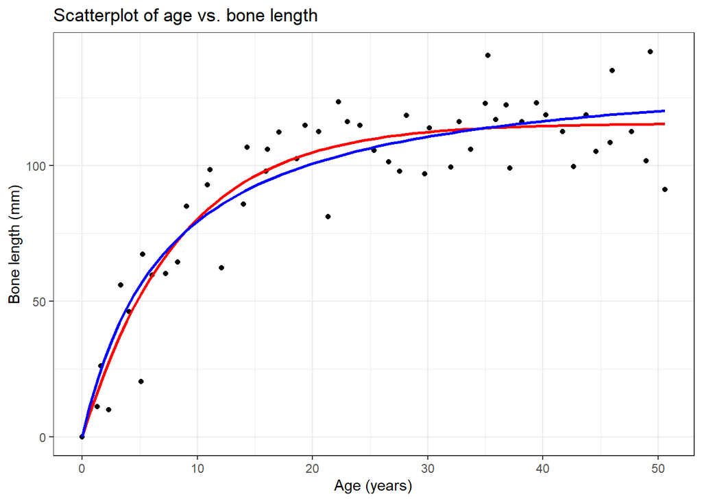

```r
# f) Make a scatterplot of the data and include both regression lines
ggplot(jaws, aes(x = age, y = bone)) +
  geom_point() +
  labs(x = "Age (years)", y = "Bone length (mm)",
       title = "Scatterplot of age vs. bone length") +
  geom_smooth(method = "nls",
              formula = y ~ a*(1-exp(-c*x)),
              se = FALSE,
              method.args = list(start = c(a = 140, c = 0.1)),
              color = "red") +
  geom_smooth(method = "nls",
              formula = y ~ a*x/(1+b*x),
              se = FALSE,
              method.args = list(start = c(a = 100, b = 0.01)),
              color = "blue") +
  theme_bw()
```

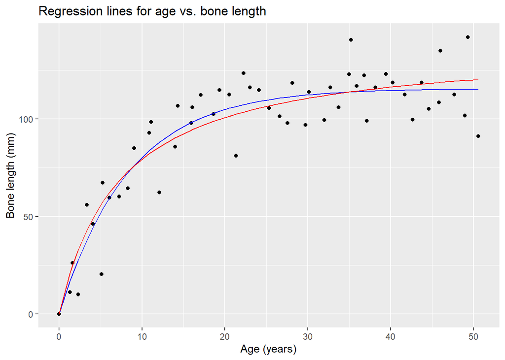

```r
# Alternative code
# f) Make a scatterplot of the data and include both regression lines

# Create predicted values for both models
jaws$exp_pred <- predict(exp_model)
jaws$mm_pred <- predict(mm_model)

# Create scatterplot with both regression lines
ggplot(jaws, aes(x = age, y = bone)) +
  geom_point() +
  geom_line(aes(y = exp_pred), color = "blue") +
  geom_line(aes(y = mm_pred), color = "red") +
  labs(x = "Age (years)", y = "Bone length (mm)",
       title = "Regression lines for age vs. bone length",
       color = "Model") +
  scale_color_manual(values = c("blue", "red"), labels = c("Exponential", "Michaelis-Menten"))
```

### **Question 6**

#### In a recent paper we read:

#### “Linear mixed effects modelling fit by restricted maximum likelihood was used to explain the variations in growth. The linear mixed effects model was generated using the lmer function in the R package lme4, with turbidity, temperature, tide, and wave action set as fixed factors and site and date set as random effects”.

#### Write down the R code to recreate their model.

```r
# # Load libraries
# library(lme4)
#
# # Load data into dataframe. Let's call it "data"...
# data <- read.table("data.txt", sep = "\t", header = T)
#
# # Generate the linear mixed effects model
# # with turbidity, temperature, tide, and wave action as fixed factors
# # and site and date as random effects
# model <- lmer(growth ~ turbidity + temperature + tide + wave_action + (1 | site) + (1 | date), data = data)
#
# # Output
# summary(model)
```

### **Question 7**

#### Researchers at the University of Arizona want to assess the germination rate of saguaros using a factorial design, with 3 levels of soil type (remnant, cultivated and restored) and 2 levels of sterilization (yes or no).

#### The same experimental design was deployed in 4 different greenhouses. Each of the unique treatments was replicated in 5 pots. 6 seeds planted in each pot.

#### a) How many fixed treatments (unique combinations) exist?

#### b) What is the total number of pots?

#### c) What is the total number of plants measured?

#### d) Write the R code that you would use to analyze these data

```r
# a)
# 3 soil types and 2 levels of sterilization
# 3 x 2 = 6 fixed treatments

# b)
# 6 fixed treatments, Replicated in 5 pots, 4 different greenhouses
# 6 x 5 x 4 = 120 total number of pots

# c)
# 6 seeds planted in each pot, 120 pots in total
# 6 x 120 = 720 total number of plants.

# d)
# R code to analyze these data:

# Load libraries
library(dplyr)
library(lme4)
# Create a data frame with the experimental design
saguaros <- expand.grid(soil_type = c("remnant", "cultivated", "restored"),
                        sterilization = c("yes", "no"),
                        greenhouse = 1:4,
                        pot = 1:5)

# Simulate germination data for each treatment
set.seed(123)
germination <- data.frame(treatment = 1:nrow(saguaros),
                          germination = rbinom(nrow(saguaros), 6, 0.5))

# Combine the design and germination data frames
data <- cbind(saguaros, germination)

# Fit the mixed-effects logistic regression model
mixed_effects <- glmer(germination/6 ~ soil_type * sterilization + (1 | greenhouse/pot),
                       data = data, family = binomial())
# Summarize the results
summary(mixed_effects)
```

```
## Generalized linear mixed model fit by maximum likelihood (Laplace
##   Approximation) [glmerMod]
##  Family: binomial  ( logit )
## Formula: germination/6 ~ soil_type * sterilization + (1 | greenhouse/pot)
##    Data: data
##
##      AIC      BIC   logLik deviance df.resid
##    163.9    186.2    -73.9    147.9      112
##
## Scaled residuals:
##      Min       1Q   Median       3Q      Max
## -0.81613  0.00002  0.33335  0.59960  2.38134
##
## Random effects:
##  Groups         Name        Variance  Std.Dev.
##  pot:greenhouse (Intercept) 8.180e-08 0.0002860
##  greenhouse     (Intercept) 3.964e-08 0.0001991
## Number of obs: 120, groups:  pot:greenhouse, 20; greenhouse, 4
##
## Fixed effects:
##                                       Estimate Std. Error z value Pr(>|z|)
## (Intercept)                         -0.4057537  0.4564483  -0.889    0.374
## soil_typecultivated                 -0.0006088  0.6455354  -0.001    0.999
## soil_typerestored                   -0.6926621  0.6891910  -1.005    0.315
## sterilizationno                      0.4057159  0.6390188   0.635    0.525
## soil_typecultivated:sterilizationno -0.4042833  0.9083118  -0.445    0.656
## soil_typerestored:sterilizationno   -1.0426255  1.0331193  -1.009    0.313
##
## Correlation of Fixed Effects:
##             (Intr) sl_typc sl_typr strlzt sl_typc:
## sl_typcltvt -0.707
## sl_typrstrd -0.662  0.468
## steriliztnn -0.714  0.505   0.473
## sl_typcltv:  0.503 -0.711  -0.333  -0.704
## sl_typrstr:  0.442 -0.312  -0.667  -0.619  0.435
## optimizer (Nelder_Mead) convergence code: 0 (OK)
## Model failed to converge with max|grad| = 0.00296322 (tol = 0.002, component 1)
```

### **Question 9**

#### 9. Dragons:

```r
# Load data
dragons_data <- load("R07_statistical_modeling/data/dragons.RData")

# Explore data
str(dragons)      # structure
```

```
## 'data.frame':    480 obs. of  5 variables:
##  $ testScore    : num  16.15 33.89 6.04 18.84 33.86 ...
##  $ bodyLength   : num  166 168 166 168 170 ...
##  $ mountainRange: Factor w/ 8 levels "Bavarian","Central",..: 1 1 1 1 1 1 1 1 1 1 ...
##  $ X            : logi  NA NA NA NA NA NA ...
##  $ site         : Factor w/ 3 levels "a","b","c": 1 1 1 1 1 1 1 1 1 1 ...
```

```r
summary(dragons)  # summary
```

```
##    testScore        bodyLength     mountainRange    X           site
##  Min.   :  0.00   Min.   :162.3   Bavarian: 60   Mode:logical   a:160
##  1st Qu.: 32.60   1st Qu.:191.8   Central : 60   NA's:480       b:160
##  Median : 51.00   Median :202.9   Emmental: 60                  c:160
##  Mean   : 50.39   Mean   :201.3   Julian  : 60
##  3rd Qu.: 67.51   3rd Qu.:213.1   Ligurian: 60
##  Max.   :100.00   Max.   :236.4   Maritime: 60
##                                   (Other) :120
```

```r
# a) Perform a simple linear regression with testScore as response and bodyLength as explanatory
dragons_lm <- lm(testScore ~ bodyLength, data = dragons)
summary(dragons_lm)
```

```
##
## Call:
## lm(formula = testScore ~ bodyLength, data = dragons)
##
## Residuals:
##     Min      1Q  Median      3Q     Max
## -56.962 -16.411  -0.783  15.193  55.200
##
## Coefficients:
##              Estimate Std. Error t value Pr(>|t|)
## (Intercept) -61.31783   12.06694  -5.081 5.38e-07 ***
## bodyLength    0.55487    0.05975   9.287  < 2e-16 ***
## ---
## Signif. codes:  0 '***' 0.001 '**' 0.01 '*' 0.05 '.' 0.1 ' ' 1
##
## Residual standard error: 21.2 on 478 degrees of freedom
## Multiple R-squared:  0.1529, Adjusted R-squared:  0.1511
## F-statistic: 86.25 on 1 and 478 DF,  p-value: < 2.2e-16
```

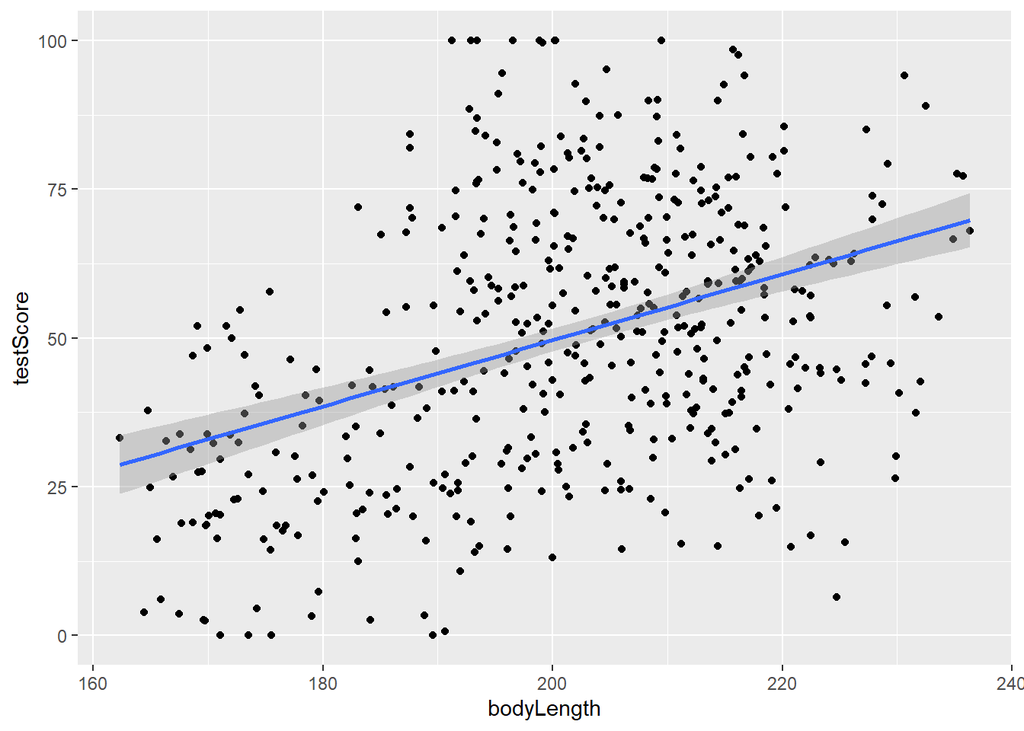

```r
# b) Plot the data with ggplot2 and add a linear regression line with confidence intervals. Hint: geom_smooth()
library(ggplot2)

ggplot(dragons, aes(x = bodyLength, y = testScore)) +
  geom_point() +
  geom_smooth(method = "lm", se = TRUE)
```

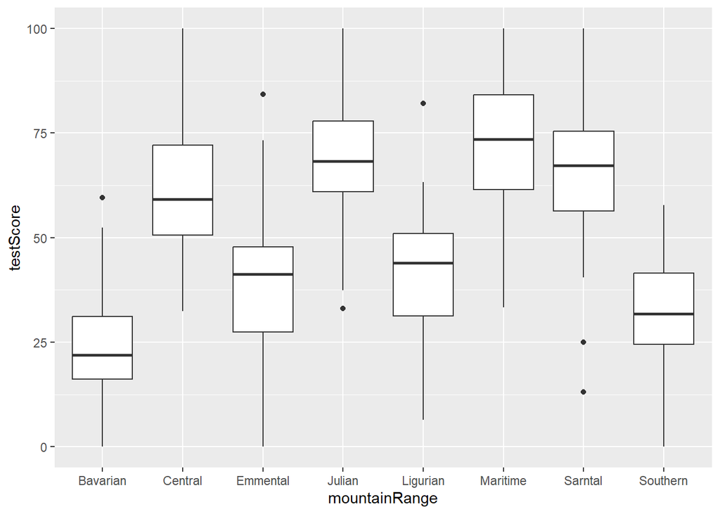

```r
# c) We collected multiple samples from 8 mountain ranges. Generate a boxplot using (or not) ggplot2 to explore this new explanatory variable
ggplot(dragons, aes(x = mountainRange, y = testScore)) +
  geom_boxplot()
```

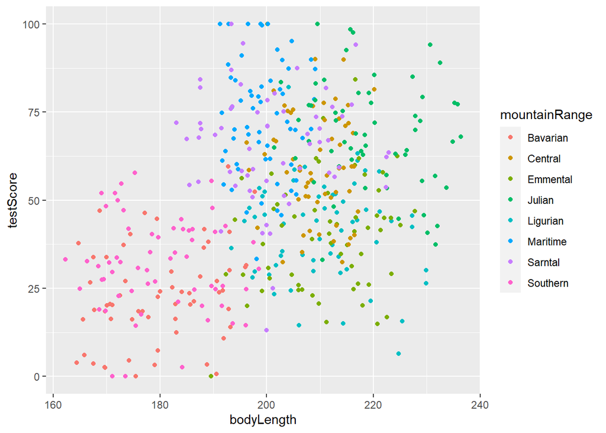

```r
# d) Now repeat the scatterplot in b) but coloring by mountain range and without linear regression line
ggplot(dragons, aes(x = bodyLength, y = testScore, color = mountainRange)) +
  geom_point()
```

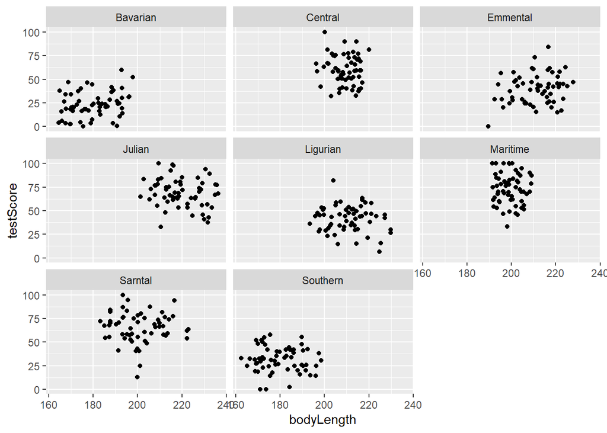

```r
# e) Instead of coloring, use facet_wrap() to separate by mountain range
ggplot(dragons, aes(x = bodyLength, y = testScore)) +
  geom_point() +
  facet_wrap(~ mountainRange)
```

```r
# f) Perform a new linear model adding mountain range and assuming that it is fixed effects
dragons_lm_fixed <- lm(testScore ~ bodyLength + mountainRange, data = dragons)
summary(dragons_lm_fixed)
```

```
##
## Call:
## lm(formula = testScore ~ bodyLength + mountainRange, data = dragons)
##
## Residuals:
##     Min      1Q  Median      3Q     Max
## -52.263  -9.926   0.361   9.994  44.488
##
## Coefficients:
##                       Estimate Std. Error t value Pr(>|t|)
## (Intercept)           20.83051   14.47218   1.439  0.15072
## bodyLength             0.01267    0.07974   0.159  0.87379
## mountainRangeCentral  36.58277    3.59929  10.164  < 2e-16 ***
## mountainRangeEmmental 16.20923    3.69665   4.385 1.43e-05 ***
## mountainRangeJulian   45.11469    4.19012  10.767  < 2e-16 ***
## mountainRangeLigurian 17.74779    3.67363   4.831 1.84e-06 ***
## mountainRangeMaritime 49.88133    3.13924  15.890  < 2e-16 ***
## mountainRangeSarntal  41.97841    3.19717  13.130  < 2e-16 ***
## mountainRangeSouthern  8.51961    2.73128   3.119  0.00192 **
## ---
## Signif. codes:  0 '***' 0.001 '**' 0.01 '*' 0.05 '.' 0.1 ' ' 1
##
## Residual standard error: 14.96 on 471 degrees of freedom
## Multiple R-squared:  0.5843, Adjusted R-squared:  0.5773
## F-statistic: 82.76 on 8 and 471 DF,  p-value: < 2.2e-16
```

```r
# g) Perform the same linear model as before but now assuming mountain range is random effects
library(lme4)

dragons_lm_random <- lmer(testScore ~ bodyLength + (1|mountainRange), data = dragons)
summary(dragons_lm_random)
```

```
## Linear mixed model fit by REML ['lmerMod']
## Formula: testScore ~ bodyLength + (1 | mountainRange)
##    Data: dragons
##
## REML criterion at convergence: 3991.2
##
## Scaled residuals:
##     Min      1Q  Median      3Q     Max
## -3.4815 -0.6513  0.0066  0.6685  2.9583
##
## Random effects:
##  Groups        Name        Variance Std.Dev.
##  mountainRange (Intercept) 339.7    18.43
##  Residual                  223.8    14.96
## Number of obs: 480, groups:  mountainRange, 8
##
## Fixed effects:
##             Estimate Std. Error t value
## (Intercept) 43.70938   17.13489   2.551
## bodyLength   0.03316    0.07865   0.422
##
## Correlation of Fixed Effects:
##            (Intr)
## bodyLength -0.924
```

```r
# h) How much of the variation in test scores is explained by the random effect (mountain range)
VarCorr(dragons_lm_random)
```

```
##  Groups        Name        Std.Dev.
##  mountainRange (Intercept) 18.43
##  Residual                  14.96
```

```r
# i) Estimate the R2 (conditional and marginal) of the mixed-effects model
library(performance)

performance::r2(dragons_lm_random)
```

```
## # R2 for Mixed Models
##
##   Conditional R2: 0.603
##      Marginal R2: 0.001
```

```r
# j) Check this last model assumptions
library(DHARMa) #model diagnostics for glm
```

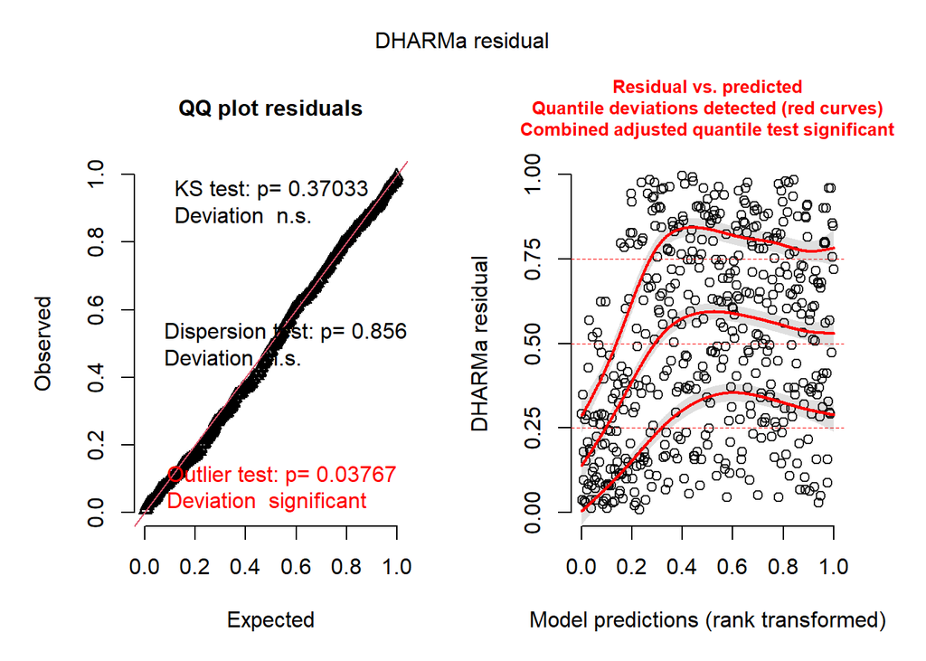

```
## Object of Class DHARMa with simulated residuals based on 250 simulations with refit = FALSE . See ?DHARMa::simulateResiduals for help.
##
## Scaled residual values: 0.096 0.288 0.032 0.068 0.268 0.428 0.036 0.036 0.028 0.032 0.288 0.348 0.088 0.028 0.084 0.072 0.132 0.104 0.152 0.08 ...
```

```r
simulateResiduals(dragons_lm_random, plot = T)
```

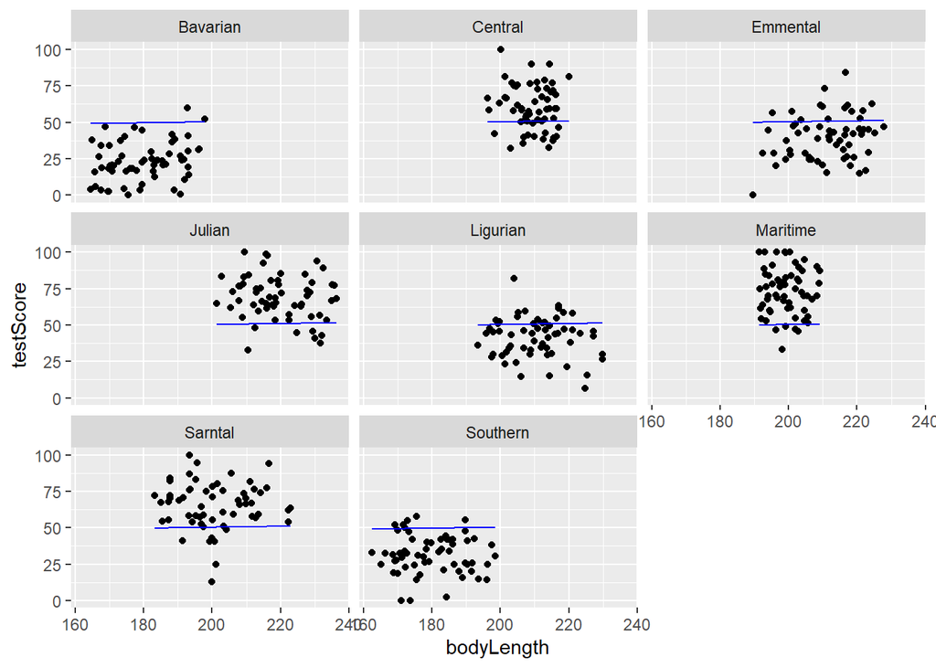

```r
# k) Include the fitted lines for each mountain range (plot from e). [Hint: predict function within geom_line layer]
dragons$predicted <- predict(dragons_lm_random, re.form = NA)

ggplot(dragons, aes(x = bodyLength, y = testScore)) +
  geom_point() +
  geom_line(aes(y = predicted, group = mountainRange), color = "blue") +
  facet_wrap(~ mountainRange)
```

### **Question 10**

#### Data in Estuaries.csv correspond to counts of invertebrates at 3-4 sites in each of 7 (randomly chosen) estuaries.

```r
# Load data
estuaries <- read.csv(file = "R07_statistical_modeling/data/Estuaries.csv", header = T)
head(estuaries)
```

```
##   X Modification Estuary Site Hydroid Total Schizoporella.errata
## 1 1     Modified     JAK    1       0    44                   15
## 2 2     Modified     JAK    1       0    42                    8
## 3 3     Modified     JAK    2       0    32                    9
## 4 4     Modified     JAK    2       0    44                   14
## 5 5     Modified     JAK    3       1    42                    6
## 6 6     Modified     JAK    3       1    48                   12
```

```r
# a) Fit a linear mixed model with Total as response and Modification as explanatory, controlling for Estuary
estuary.lme <- lmer(Total~Modification+(1|Estuary), data=estuaries)

# b) Estimate the R2 (conditional and marginal) of this model
r2(estuary.lme)
```

```
## # R2 for Mixed Models
##
##   Conditional R2: 0.553
##      Marginal R2: 0.267
```

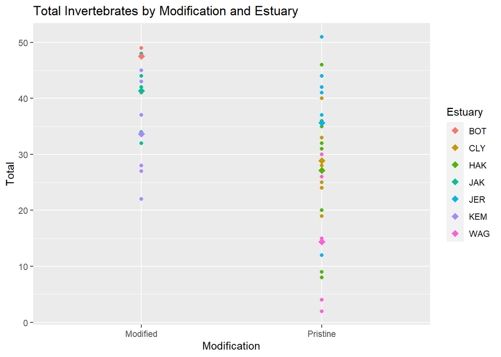

```r
# c) Plot the data with ggplot2 in a way that helps you understand the different effects
# jitterplot with the effects of estuaries
ggplot(estuaries, aes(x = Modification, y = Total, color = Estuary)) +
  geom_point() +
  stat_summary(fun = mean, geom = "point", shape = 18, size = 3) +
  labs(title = "Total Invertebrates by Modification and Estuary")
```

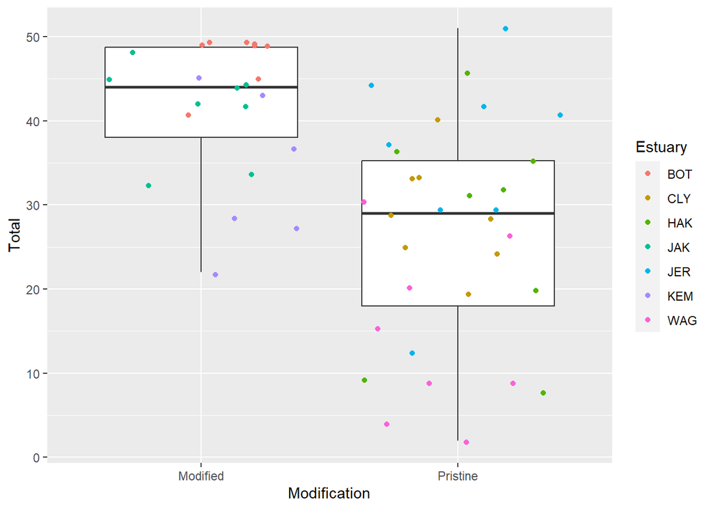

```r
ggplot(estuaries, aes(x = Modification, y = Total)) +
  geom_boxplot()+
  geom_jitter(aes(color=Estuary))
```

```r
# d) Include the variable Site as a random effect.
# Do you think this corresponds to a crossed or a nested design?
# Fit the linear mixed model with Site as a random effect
model_site <- lmer(Total ~ Modification + (1 | Estuary) + (1 | Estuary:Site), data = estuaries)
    # Nested design because each site is nested within a specific estuary.


# e) What are the R2 (conditional and marginal) of the model including Site
r2(model_site)
```

```
## # R2 for Mixed Models
##
##   Conditional R2: 0.774
##      Marginal R2: 0.270
```

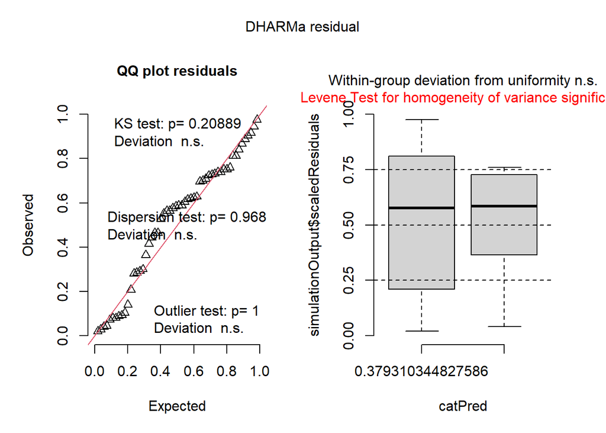

```
## Object of Class DHARMa with simulated residuals based on 250 simulations with refit = FALSE . See ?DHARMa::simulateResiduals for help.
##
## Scaled residual values: 0.584 0.552 0.208 0.576 0.528 0.732 0.604 0.292 0.588 0.976 0.08 0.628 0.916 0.868 0.812 0.904 0.74 0.74 0.464 0.62 ...
```

```r
# f) Check the model assumptions
library(DHARMa)
simulateResiduals(model_site, plot = T)
```

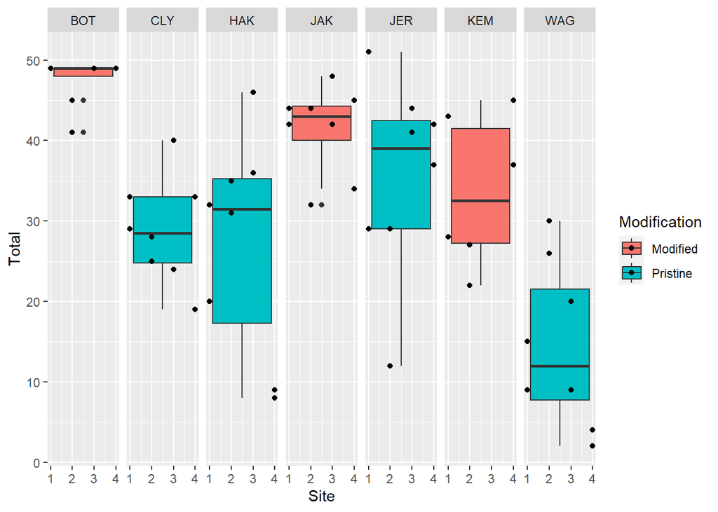

```r
# g) Plot the data trying to include Site
ggplot(estuaries, aes(x=Site, y=Total, fill=Modification))+
  geom_boxplot()+
  geom_point()+
  facet_grid(~Estuary)
```

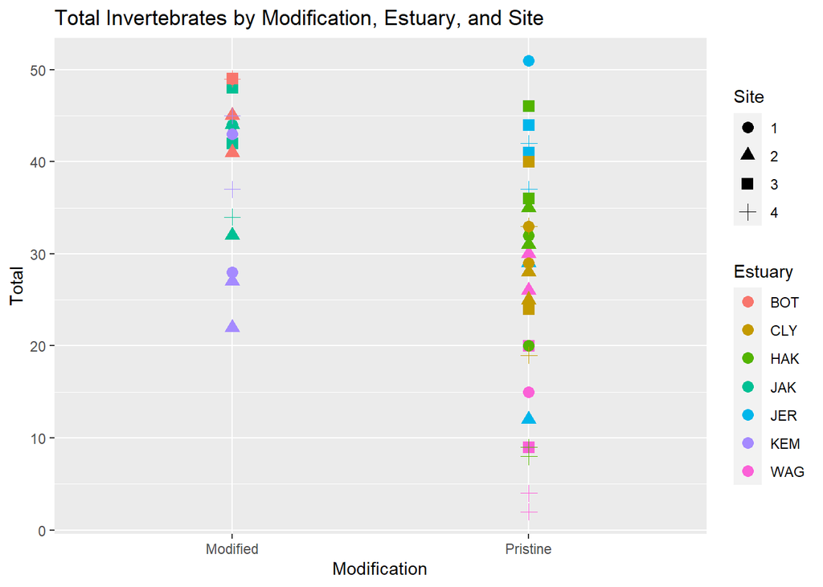

```r
ggplot(estuaries, aes(x = Modification, y = Total, color = Estuary)) +
  geom_point(aes(shape = factor(Site)), size = 3) +
  labs(title = "Total Invertebrates by Modification, Estuary, and Site") +
  scale_shape_discrete(name = "Site")
```

```r
# h) Transform the variable Hydroid to presence/absence data
estuaries$Hydroid <- ifelse(estuaries$Hydroid==0, 0 , 1) # Not recommended since it changes the raw data

# i) Fit a generalized linear mixed model (GLMM) with this transformed variable as Response and the same fixed and random effects as in d). [Hint: function glmer]
hydroid.GLM <- glmer(Hydroid~Modification + (1|Estuary/Site), data = estuaries, family = "binomial")
summary(hydroid.GLM)
```

```
## Generalized linear mixed model fit by maximum likelihood (Laplace
##   Approximation) [glmerMod]
##  Family: binomial  ( logit )
## Formula: Hydroid ~ Modification + (1 | Estuary/Site)
##    Data: estuaries
##
##      AIC      BIC   logLik deviance df.resid
##     57.1     65.0    -24.5     49.1       50
##
## Scaled residuals:
##      Min       1Q   Median       3Q      Max
## -1.06063 -0.25028 -0.05443  0.25475  0.98719
##
## Random effects:
##  Groups       Name        Variance Std.Dev.
##  Site:Estuary (Intercept) 14.45    3.802
##  Estuary      (Intercept)  1.13    1.063
## Number of obs: 54, groups:  Site:Estuary, 27; Estuary, 7
##
## Fixed effects:
##                      Estimate Std. Error z value Pr(>|z|)
## (Intercept)            -5.710      2.419  -2.360   0.0183 *
## ModificationPristine    6.534      3.140   2.081   0.0375 *
## ---
## Signif. codes:  0 '***' 0.001 '**' 0.01 '*' 0.05 '.' 0.1 ' ' 1
##
## Correlation of Fixed Effects:
##             (Intr)
## MdfctnPrstn -0.888
```

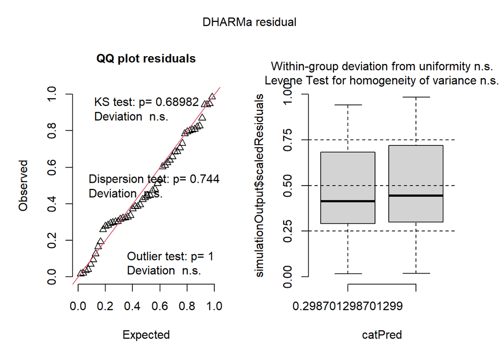

```
## Object of Class DHARMa with simulated residuals based on 250 simulations with refit = FALSE . See ?DHARMa::simulateResiduals for help.
##
## Scaled residual values: 0.6382768 0.3853122 0.8086934 0.01626812 0.9424474 0.9426142 0.5324421 0.3949867 0.82084 0.4799594 0.8009645 0.03378411 0.3224195 0.3157432 0.602992 0.6115054 0.276876 0.8050706 0.7838545 0.5106198 ...
```

```r
# j) Check the model assumptions
simulateResiduals(hydroid.GLM, plot = T)
```

```r
r2(hydroid.GLM)
```

```
## # R2 for Mixed Models
##
##   Conditional R2: 0.888
##      Marginal R2: 0.358
```

## **Problem Set 8: Time Series and Spatial Analysis**

### **Question 1**

#### Write a function to calculate the 3-point moving average for an input vector.

#### The formula is: y_i^’= (y_(i-1)+y_i+y_(i+1))/3

```r
moving_average <- function(x) {
  n <- length(x)
  y <- numeric(n) # Initialize an empty vector to store the moving average values

  for (i in 2:(n - 1)) {
    y[i] <- (x[i - 1] + x[i] + x[i + 1]) / 3
  }

  return(y)
}

# Example:
input_vector <- c(1, 2, 3, 4, 5, 6, 7)
result <- moving_average(input_vector)
print(result)
```

```
## [1] 0 2 3 4 5 6 0
```

### **Question 2**

#### Read the temp.txt file. The data correspond to monthly average temperatures. Time series analysis:

```r
# Load packages
library(TTR)
library(forecast)
```

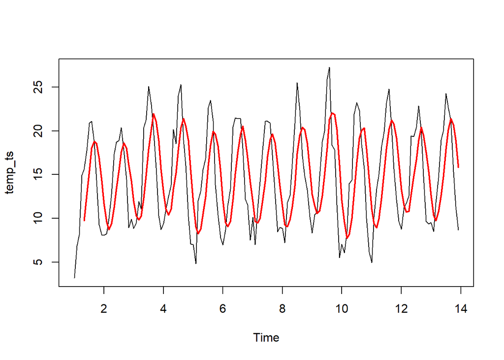

```r
# 2. Read the temp.txt file. The data correspond to monthly average temperatures.
temp<-read.table("R08_timeseries_spatialanalysis/temp.txt", header=T)

# a) Plot the time series data. [Hint: first you need to create a monthly time series object]
temp_ts<-ts(temp$temps, frequency=12)
plot(temp_ts)

# b) Calculate the 5-point moving average and plot it together with the time series
temp_ma<-SMA(temp_ts, n = 5)
lines(temp_ma, col="red", lwd=2)
```

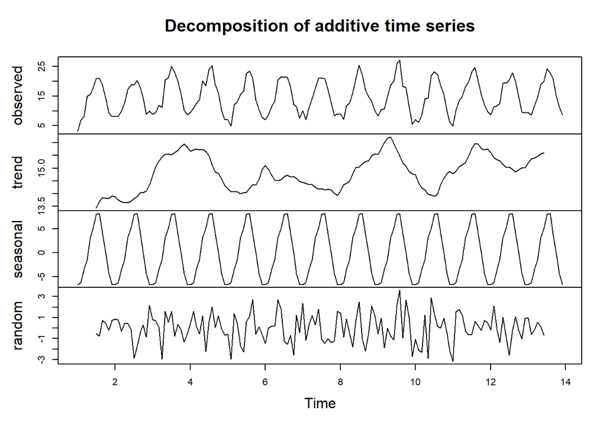

```r
# c) Decompose the time series into seasonal, trend and residual error components
temp_decomp<-decompose(temp_ts)
plot(temp_decomp)
```

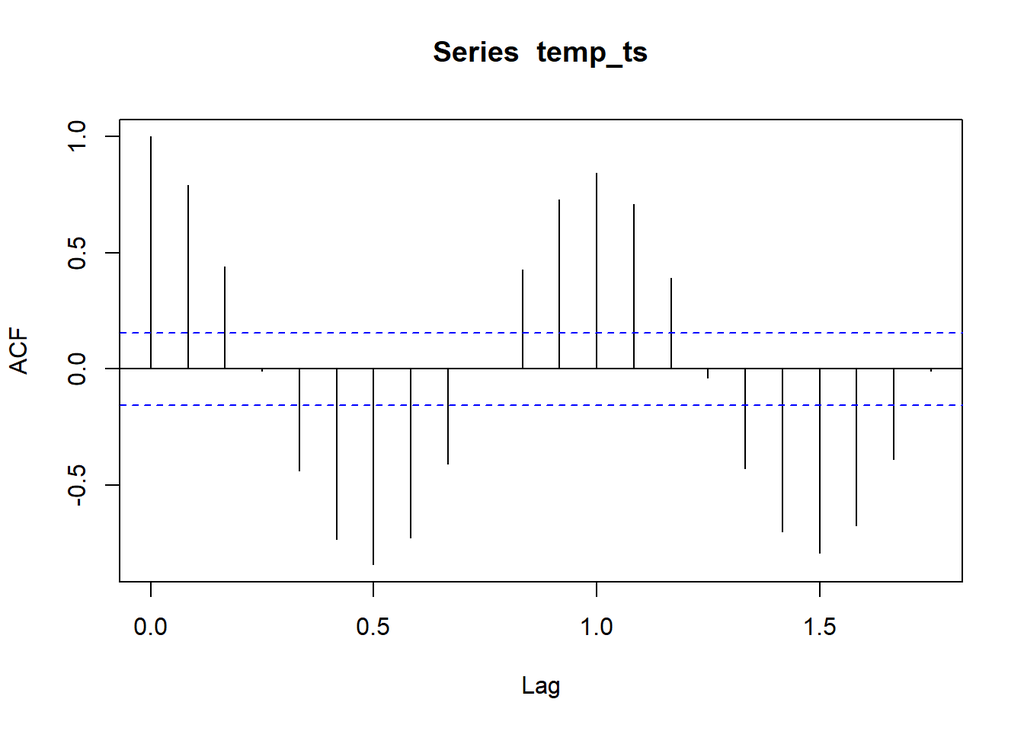

```r
# d) Generate a temporal correlogram to assess the autocorrelation of the time series
acf(temp_ts)
```

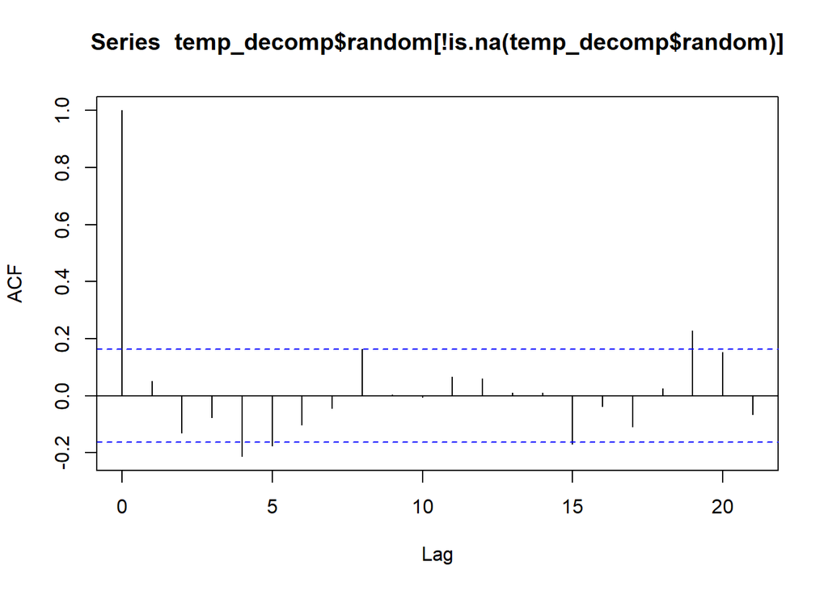

```r
# e) Generate a new correlogram but removing the trend and seasonal variation
acf(temp_decomp$random[!is.na(temp_decomp$random)])
```

```r
# f) Find the best ARIMA model using the forecast package
temp_fit<-auto.arima(temp_ts)
summary(temp_fit)
```

```
## Series: temp_ts
## ARIMA(0,0,1)(2,1,0)[12]
##
## Coefficients:
##          ma1     sar1     sar2
##       0.2456  -0.5212  -0.3233
## s.e.  0.0774   0.0823   0.0827
##
## sigma^2 = 3.772:  log likelihood = -300.76
## AIC=609.52   AICc=609.81   BIC=621.4
##
## Training set error measures:
##                     ME     RMSE      MAE       MPE     MAPE      MASE
## Training set 0.2384692 1.846384 1.498262 0.2682136 11.90101 0.8327783
##                     ACF1
## Training set 0.005413047
```

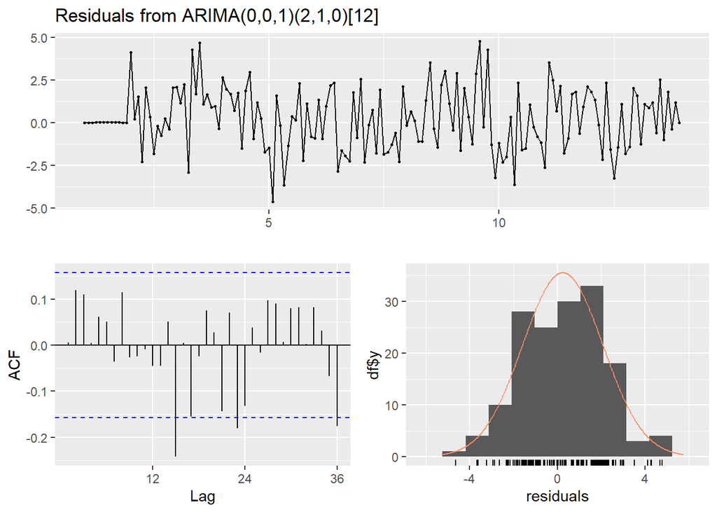

```
##
##  Ljung-Box test
##
## data:  Residuals from ARIMA(0,0,1)(2,1,0)[12]
## Q* = 38.688, df = 21, p-value = 0.01069
##
## Model df: 3.   Total lags used: 24
```

```r
checkresiduals(temp_fit)
```

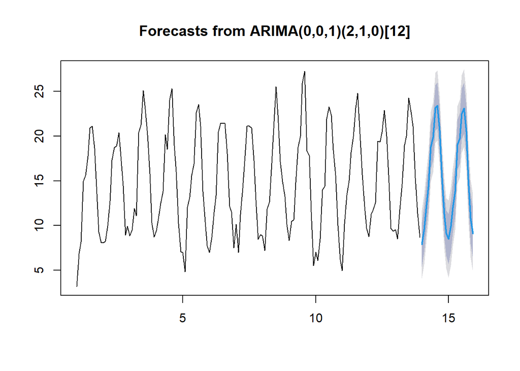

```r
# g) Estimate future values using the previous ARIMA model and plot the results
temp_fcast<-forecast(temp_fit)
plot(temp_fcast)
```

### **Question 3**

#### Love for Spain

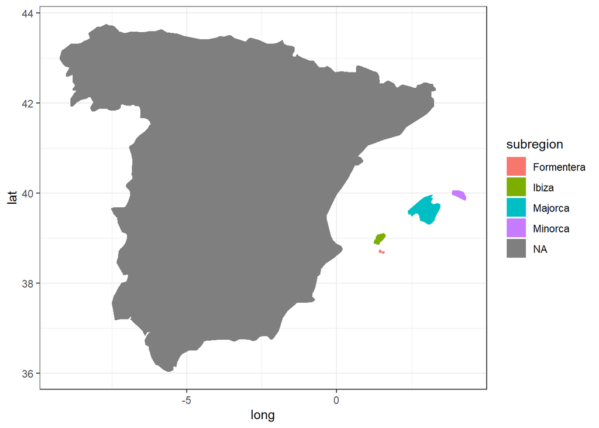

```r
# Load packages
library(maps)
library(ggplot2)
library(viridis)
# Download the map of Spain.
spain_map<-map_data("world", region="spain")

# a) Make a basic map of Spain
ggplot(spain_map) +
  geom_polygon(aes(x = long, y = lat, group = group, fill = subregion)) +
  theme_bw()
```

```r
# b) Get information on the population of Spanish cities
# and make a map of Spain including the locations and population of Spanish cities.
cities<-get('world.cities')
head(cities)
```

```
##                 name country.etc   pop   lat  long capital
## 1 'Abasan al-Jadidah   Palestine  5629 31.31 34.34       0
## 2 'Abasan al-Kabirah   Palestine 18999 31.32 34.35       0
## 3       'Abdul Hakim    Pakistan 47788 30.55 72.11       0
## 4 'Abdullah-as-Salam      Kuwait 21817 29.36 47.98       0
## 5              'Abud   Palestine  2456 32.03 35.07       0
## 6            'Abwein   Palestine  3434 32.03 35.20       0
```

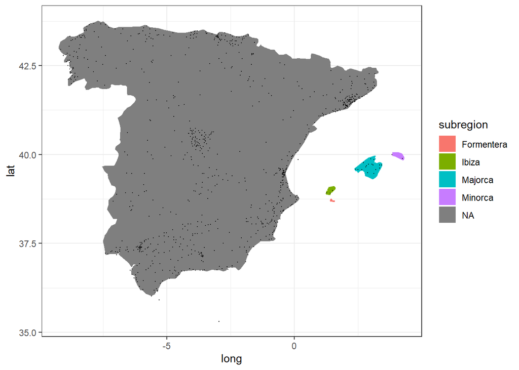

```r
cities_spain<-cities[cities$country.etc == 'Spain',]

ggplot(spain_map) +
  geom_polygon(aes(x = long, y = lat, group = group, fill = subregion)) +
  geom_point(data = cities_spain, aes(x = long, y = lat), size = 0.1) +
  theme_bw()
```

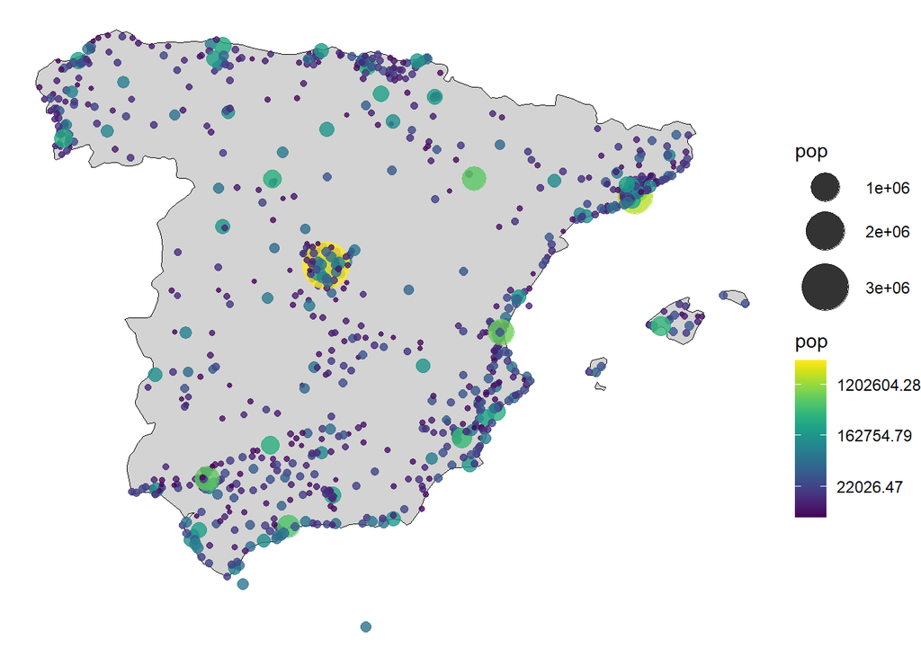

```r
ggplot(spain_map) +
  geom_polygon(aes(x = long, y = lat, group = group), fill = 'lightgray', color = "black", size = 0.1) +
  geom_point(data = cities_spain, aes(x = long, y = lat, size = pop, color = pop), alpha = 0.8) +
  scale_size_continuous(range = c(1, 12)) +
  scale_color_viridis(trans = "log") +
  theme_void()
```

### **Question 4**

#### Download GBIF georeferenced occurrence data of the Pyrenean desman (Galemys pyrenaicus) and make a map of its geographical distribution

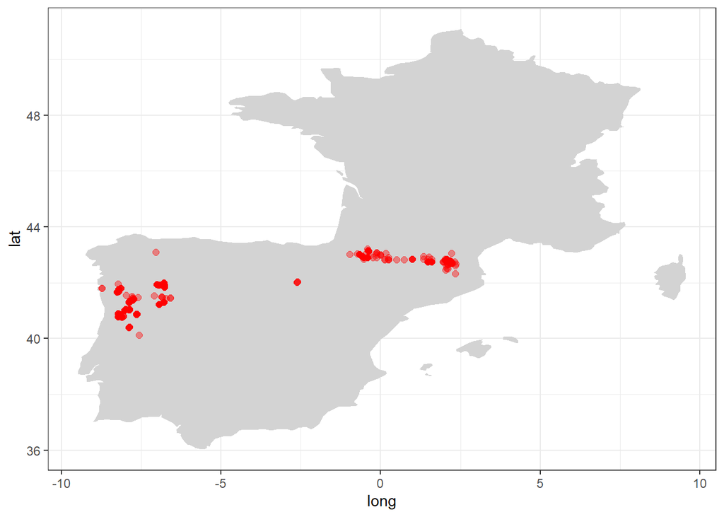

```r
# Load packages
library(rgbif)

# Download from GBIF
desman_gbif<-occ_search(scientificName = "Galemys pyrenaicus", hasCoordinate = T)

# Convert to data frame
desman<-as.data.frame(desman_gbif$data[,c("decimalLatitude", "decimalLongitude")])

# Download maps for geographical distribution
southEU_map<-map_data("world", region=c("Spain", "Portugal", "France", "Andorra"))

# Plot distribution
ggplot(southEU_map)+
  geom_polygon(aes(x = long, y = lat, group=group), fill="lightgray")+
  geom_point(data=desman, aes(x=decimalLongitude, y=decimalLatitude), color="red", alpha=0.4, size=2)+
  theme_bw()
```

## **Problem Set 9: Diversity Analysis**

### **Question 1**

#### Diversity Analysis basics

```r
# Load the dune_bio.txt dataset.
# Species should be in columns and sites in rows.
dune <-read.table("R09_diversity_analysis/data/dune_bio.txt", header=T)
head(dune)
```

```
##   Sites Belper Empnig Junbuf Junart Airpra Elepal Rumace Viclat Brarut Ranfla
## 1     2      3      0      0      0      0      0      0      0      0      0
## 2    13      0      0      3      0      0      0      0      0      0      2
## 3     4      2      0      0      0      0      0      0      0      2      0
## 4    16      0      0      0      3      0      8      0      0      4      2
## 5     6      0      0      0      0      0      0      6      0      6      0
## 6     1      0      0      0      0      0      0      0      0      0      0
##   Cirarv Hyprad Leoaut Potpal Poapra Calcus Tripra Trirep Antodo Salrep Achmil
## 1      0      0      5      0      4      0      0      5      0      0      3
## 2      0      0      2      0      2      0      0      2      0      0      0
## 3      2      0      2      0      4      0      0      1      0      0      0
## 4      0      0      0      0      0      3      0      0      0      0      0
## 5      0      0      3      0      3      0      5      5      3      0      2
## 6      0      0      0      0      4      0      0      0      0      0      1
##   Poatri Chealb Elyrep Sagpro Plalan Agrsto Lolper Alogen Brohor
## 1      7      0      4      0      0      0      5      2      4
## 2      9      1      0      2      0      5      0      5      0
## 3      5      0      4      5      0      8      5      2      3
## 4      2      0      0      0      0      7      0      4      0
## 5      4      0      0      0      5      0      6      0      0
## 6      2      0      4      0      0      0      7      0      0
```

```r
# Load packages
library(vegan)
# a) Calculate the total number of individuals of all species
sum(dune)
```

```
## [1] 895
```

```r
# b) Calculate the total number of individuals for each species
colSums(dune)
```

```
##  Sites Belper Empnig Junbuf Junart Airpra Elepal Rumace Viclat Brarut Ranfla
##    210     13      2     13     18      5     25     18      4     49     14
## Cirarv Hyprad Leoaut Potpal Poapra Calcus Tripra Trirep Antodo Salrep Achmil
##      2      9     54      4     48     10      9     47     21     11     16
## Poatri Chealb Elyrep Sagpro Plalan Agrsto Lolper Alogen Brohor
##     63      1     26     20     26     48     58     36     15
```

```r
# c) Calculate the average number of individuals for each species
colMeans(dune)
```

```
##  Sites Belper Empnig Junbuf Junart Airpra Elepal Rumace Viclat Brarut Ranfla
##  10.50   0.65   0.10   0.65   0.90   0.25   1.25   0.90   0.20   2.45   0.70
## Cirarv Hyprad Leoaut Potpal Poapra Calcus Tripra Trirep Antodo Salrep Achmil
##   0.10   0.45   2.70   0.20   2.40   0.50   0.45   2.35   1.05   0.55   0.80
## Poatri Chealb Elyrep Sagpro Plalan Agrsto Lolper Alogen Brohor
##   3.15   0.05   1.30   1.00   1.30   2.40   2.90   1.80   0.75
```

```r
# d) Calculate the total number of individuals for each site
rowSums(dune)
```

```
##  [1] 44 46 49 49 54 19 48 48 32 38 53 43 51 45 43 51 38 50 47 47
```

```r
# e) Calculate the average number of individuals for each site
rowMeans(dune)
```

```
##  [1] 1.4193548 1.4838710 1.5806452 1.5806452 1.7419355 0.6129032 1.5483871
##  [8] 1.5483871 1.0322581 1.2258065 1.7096774 1.3870968 1.6451613 1.4516129
## [15] 1.3870968 1.6451613 1.2258065 1.6129032 1.5161290 1.5161290
```

```r
# f) Function to report the median number of individuals for each species and each site
median_sps_sites<-function(x){
  cat("The median number of inds per sp is", apply(x, 2, median), "and for sites is", apply(x, 1, median))
}

# Median number of individuals for each species
median_sps_sites(dune)
```

```
## The median number of inds per sp is 10.5 0 0 0 0 0 0 0 0 2 0 0 0 2 0 3 0 0 2 0 0 0 4 0 0 0 0 1.5 2 0 0 and for sites is 0 0 0 0 0 0 0 0 0 0 0 0 0 0 0 0 0 0 0 0
```

```r
# g) Transform the dataset to relative abundances using decostand()
dune_relabun <-decostand(dune, method = "total")
rowSums(dune_relabun)
```

```
##  [1] 1 1 1 1 1 1 1 1 1 1 1 1 1 1 1 1 1 1 1 1
```

```r
# h) Standardize the dataset into the range 0 to 1 using decostand()
dune_range<-decostand(dune, method = "range")

# i) Standardize the dataset to mean=0 and variance=1 using decostand()
dune_stand<-decostand(dune, method = "standardize")
```

### **Question 2**

#### Write a function to calculate the observed richness of a vector representing the abundances of different species in a community.

```r
richness <- function(abundances) {
  sum(abundances > 0)
}


# Test
abundances <- c(0, 2, 0, 1, 4, 0, 3) # abundances of diff species

richness(abundances) # four species with >0 abundances
```

```
## [1] 4
```

### **Question 3**

#### Write a function to calculate the Shannon-Wiener diversity index of a vector representing the abundances of different species in a community.

```r
shannon_diversity <- function(abundances) {
  abundances <- abundances[abundances > 0]  # Filter out zero abundance values
  prop <- abundances / sum(abundances)  # Calculate proportion of each species
  log_prop <- log(prop)  # Take the natural logarithm of each proportion
  -sum(prop * log_prop)  # Calculate the Shannon-Wiener index
}

abundances <- c(5, 2, 0, 1, 4, 5, 3)
shannon_diversity(abundances)
```

```
## [1] 1.679648
```

### **Question 4**

#### Write a function that calculates both the observed richness and the Shannon-Wiener diversity index for each community in a matrix, and writes an output table with the results.

#### You can use the vegan built-in functions.

#### Test your function with the dune_bio.txt dataset.

```r
diversity_summary <- function(community_matrix) {
  # Calculate observed richness
  richness <- apply(community_matrix, 1, function(row) sum(row > 0))

  # Calculate Shannon-Wiener diversity index
  shannon_wiener <- apply(community_matrix, 1, function(row) {
    # Use the vegan built-in function to calculate Shannon-Wiener diversity index
    diversity(row, index = "shannon")
  })

  # Create an output table with the results
  output_table <- data.frame(Observed_Richness = richness,
                             Shannon_Wiener = shannon_wiener)

  return(output_table)
}


# Test with dune.bio dataset
dune <- read.table("R09_diversity_analysis/data/dune_bio.txt", header = T)
head(dune)
```

```
##   Sites Belper Empnig Junbuf Junart Airpra Elepal Rumace Viclat Brarut Ranfla
## 1     2      3      0      0      0      0      0      0      0      0      0
## 2    13      0      0      3      0      0      0      0      0      0      2
## 3     4      2      0      0      0      0      0      0      0      2      0
## 4    16      0      0      0      3      0      8      0      0      4      2
## 5     6      0      0      0      0      0      0      6      0      6      0
## 6     1      0      0      0      0      0      0      0      0      0      0
##   Cirarv Hyprad Leoaut Potpal Poapra Calcus Tripra Trirep Antodo Salrep Achmil
## 1      0      0      5      0      4      0      0      5      0      0      3
## 2      0      0      2      0      2      0      0      2      0      0      0
## 3      2      0      2      0      4      0      0      1      0      0      0
## 4      0      0      0      0      0      3      0      0      0      0      0
## 5      0      0      3      0      3      0      5      5      3      0      2
## 6      0      0      0      0      4      0      0      0      0      0      1
##   Poatri Chealb Elyrep Sagpro Plalan Agrsto Lolper Alogen Brohor
## 1      7      0      4      0      0      0      5      2      4
## 2      9      1      0      2      0      5      0      5      0
## 3      5      0      4      5      0      8      5      2      3
## 4      2      0      0      0      0      7      0      4      0
## 5      4      0      0      0      5      0      6      0      0
## 6      2      0      4      0      0      0      7      0      0
```

```r
diversity_summary(dune)
```

```
##    Observed_Richness Shannon_Wiener
## 1                 11       2.335037
## 2                 11       2.101662
## 3                 14       2.511413
## 4                  9       1.951556
## 5                 12       2.434118
## 6                  6       1.570859
## 7                 13       2.479643
## 8                 15       2.613520
## 9                  8       1.570696
## 10                 9       1.868823
## 11                13       2.430346
## 12                10       2.135937
## 13                14       2.519526
## 14                10       1.920644
## 15                11       2.293734
## 16                 9       1.914730
## 17                 8       1.835171
## 18                10       1.987159
## 19                10       2.142728
## 20                14       2.524462
```